# Pesquisas eleitorais publicadas mudam o voto?

Síntese sistemática de evidências, conduzida com agentes de IA, sobre os efeitos *bandwagon* e *underdog* e o comparecimento

Autores

Afiliações

Felipe Lamarca

MAPE/IESP-UERJ

Lucas Berti

IESP-UERJ

Versão

30/09/2026

Palavras-chave

pesquisas eleitorais, efeito bandwagon, efeito underdog, comparecimento eleitoral, síntese sistemática de evidências, síntese sem meta-análise, GRADE, Brasil

# Mensagens principais

- **Apoio ao líder.** Nas duas maiores células, os 8 experimentos apontaram a favor do líder, mas a evidência é muito incerta (⊕◯◯◯ certeza muito baixa).
- **Comparecimento.** Receber, por carta, pesquisa que mostra disputa apertada, em vez de folgada, provavelmente não muda o comparecimento além de 2 pontos percentuais para mais ou para menos (1 experimento de campo; ⊕⊕⊕◯ certeza moderada).
- **Brasil.** Sem a SciELO na busca, o único estudo brasileiro (Araujo e Gatto 2021a) analisa apuração parcial, não pesquisa.
- **O que não se sabe.** A evidência não diz de quanto é o efeito das pesquisas sobre o voto, e tampouco permite afirmar que elas não têm efeito. Sozinha, a evidência não demonstra que a divulgação de pesquisas muda votos, nem que é inócua.
- **Como foi feita.** Agentes de IA conduziram as etapas depois do protocolo. Conferimos em bloco partes da busca, da seleção e da extração (Apêndice G), e o risco de viés e a certeza da evidência foram julgados só por IA, sem validação humana.

# Resumo

**Contexto.** Regular pesquisas exige saber se mudam votos.

**Objetivos.** Avaliar se pesquisas publicadas mudam voto ou comparecimento, e em que direção (*bandwagon* ou *underdog*).

**Métodos.** Experimentos, quase-experimentos e painéis desde 2010 sobre pesquisas, projeções, boca de urna ou apuração parcial. Busca no OpenAlex, na BDTD e por citação (19 e 20/09/2026). Risco de viés (RoB 2, ROBINS-I V2, EPOC), direção por célula (SWiM) e GRADE. Agentes de IA conduziram as etapas pós-protocolo; conferimos em bloco partes de busca, seleção e extração.

**Resultados.** Dos 41 estudos, 27 (n de 12 eleitorados a 453.016 seções) formaram 18 células. Nas duas maiores, os 8 experimentos apontaram a favor do líder (proporção 1,00; IC 95% 0,40 a 1,00 em cada), mas a evidência é muito incerta (⊕◯◯◯ certeza muito baixa). Pesquisa apertada, e não folgada, provavelmente não muda o comparecimento além de ±2 p.p. (⊕⊕⊕◯ certeza moderada). Ter visto pesquisas pode aumentá-lo; num jogo *online*, projeções longe de 50:50 podem reduzi-lo (⊕⊕◯◯ certeza baixa). O único estudo brasileiro analisa apuração parcial.

**Limitações.** De 1 a 4 estudos por célula, quase só de laboratório e vinheta, todos os experimentos com algumas preocupações ou risco alto de viés; risco de viés e certeza julgados só por IA; triagem sem validação cega; 338 de 522 relatos não recuperados.

**Conclusões.** Não se sabe se pesquisas mudam o voto, nem em quanto.

**Registro e financiamento.** Não registrada; sem financiamento.

**Palavras-chave:** pesquisas eleitorais; efeito *bandwagon*; efeito *underdog*; comparecimento eleitoral; síntese sistemática de evidências; síntese sem meta-análise; GRADE; Brasil.

# Abstract

**Background.** Regulating polls requires knowing whether they change votes.

**Objectives.** To assess whether published polls change votes or turnout, and in which direction (bandwagon or underdog).

**Methods.** Experiments, quasi-experiments and panels since 2010 on polls, forecasts, exit polls or partial counts. OpenAlex, BDTD and citation searches, September 2026. Risk of bias (RoB 2, ROBINS-I V2, EPOC), direction per cell (SWiM) and GRADE. AI agents conducted the post-protocol stages; we checked parts of search, selection and extraction *en bloc*.

**Results.** Of 41 studies, 27 (n from 12 electorates to 453,016 polling stations) formed 18 cells. In each of the two largest, all 4 experiments pointed towards the leader (proportion 1.00; 95% CI 0.40 to 1.00), but we are very uncertain about this effect (⊕◯◯◯ very low certainty). A close rather than lopsided poll probably does not change turnout by over 2 percentage points (⊕⊕⊕◯ moderate certainty). Having seen poll releases may increase turnout, and, in an online game, forecasts far from 50:50 may reduce it (⊕⊕◯◯ low certainty). The only Brazilian study concerns partial counts.

**Limitations.** One to four studies per cell, mostly laboratory or vignette, every experiment at some concerns or high risk of bias; risk of bias and certainty judged by AI alone; screening without blind validation; 338 of 522 reports not retrieved.

**Conclusions.** Whether polls change votes, and by how much, is unknown.

**Registration and funding.** Not registered; no funding.

**Keywords:** election polls; bandwagon effect; underdog effect; voter turnout; systematic evidence synthesis; synthesis without meta-analysis; GRADE; Brazil.

# Como esta síntese foi feita

Parte deste trabalho foi construir a ferramenta que o conduziu. Um de nós, Felipe Lamarca, desenvolveu, com apoio de agentes de IA, a *skill* `revisao-sistematica` para o Claude Code, com três *skills* irmãs (download de textos completos por fontes legítimas, fichamento por *codebook* e referências em BibTeX), e o livro de método *Revisão sistemática de ponta a ponta* (Lamarca 2026), publicado em https://felipelamarca.com/Systematic-Review/. O livro, que parte da proposta *O que funciona?* (Schaefer, Borges e Freitas 2025) e a estende com as normas de Cochrane, Campbell, PRISMA e GRADE, traz os protocolos, as regras e os critérios de cada etapa que a *skill* executa. A cópia da *skill* usada nesta síntese está no pacote de replicação.

A *skill* divide o trabalho entre pessoas, modelos de linguagem e *scripts*. Um coordenador de IA roda a ferramenta e distribui as tarefas em volume, como triar registros e ler textos completos, entre subagentes – isto é, outras instâncias de modelos –, enquanto aos *scripts* cabe o que não pede julgamento: a deduplicação, o fluxo PRISMA, a conferência dos trechos citados e as contas da síntese. Já o que pede julgamento humano vira uma pendência, e os produtos da ferramenta saem marcados como rascunho enquanto houver pendência aberta. Cada comando grava um registro (*log*) que só aceita acréscimos, com o que foi feito, por quem e quando.

A revisão anda por etapas, e cada uma termina num portão, ou seja, num ponto de aprovação antes da etapa seguinte: G1, a pergunta; G2, o protocolo; G3, a busca; G4, a triagem de títulos e resumos; G5, a elegibilidade no texto completo; G6, o piloto de extração; G7, a extração e o risco de viés; G8, a síntese e a certeza da evidência; e G9, o relato. Em cada portão, a ferramenta confere os arquivos da etapa e, no modo de autopiloto, aprova sozinha quando as conferências passam; o que precisaria de confirmação humana fica como pendência. Nesta síntese, aprovamos G1, G2 e G9 e revisamos o trabalho dos agentes em G3, G5 e G6. Em G4 e G7, a revisão humana foi parcial, e, em G8, a certeza da evidência segue sem validação humana; as pendências estão listadas no Apêndice G.

As mudanças de método feitas depois do protocolo viraram emendas numeradas, com a data e o momento em relação aos dados (Apêndice B). Daqui em diante, o texto relata a síntese propriamente dita: o problema, os métodos, os resultados e o que eles implicam.

# 1 Introdução

## 1.1 O problema e o debate brasileiro

Pesquisas eleitorais estão entre as informações mais difundidas de uma campanha. Regular sua divulgação pressupõe responder a uma pergunta: ver uma pesquisa muda o voto de quem a vê e, se muda, a favor de quem lidera ou de quem está atrás?

A Lei das Eleições obriga o registro da pesquisa na Justiça Eleitoral até cinco dias antes da divulgação e trata como crime a divulgação de pesquisa fraudulenta (Brasil 1997; Tribunal Superior Eleitoral 2019). Não há período de silêncio: o embargo criado pela Lei nº 11.300/2006 foi declarado inconstitucional pelo STF por restringir o direito do eleitor à informação, sem que o efeito das pesquisas sobre o voto entrasse no fundamento (Supremo Tribunal Federal 2006).

A pesquisa de boca de urna, feita no dia da eleição (e não o crime eleitoral homônimo), só pode ser divulgada a partir das 17h de Brasília (Tribunal Superior Eleitoral 2019). Desde 2022, a votação termina nesse horário em todo o país, quando começa a divulgação da apuração (Tribunal Superior Eleitoral 2021, 2022). Em 2018, a apuração para presidente só começou a ser divulgada às 19h (Tribunal Superior Eleitoral 2018).

Depois do primeiro turno de 2022, o PL nº 2.567/2022, na Câmara, propôs tornar crime a publicação de pesquisa que diverge do resultado além da margem de erro (Câmara dos Deputados 2022), e o PL nº 2.558/2022, no Senado, propôs punir as empresas (Senado Federal 2022). Em 24/09/2026, nenhum dos dois tinha sido votado em plenário.

O debate sobre os “erros das pesquisas” mistura outras duas perguntas, que não são a desta síntese. Uma é a da precisão, que Meireles e Russo (2022), com mais de 2 mil pesquisas de 2012 a 2020, acham comparável à de outros países; a outra, a da mudança de opinião na reta final, a que Pereira e Nunes (2024) atribuem parte da distância entre pesquisas e urnas em 2022.

## 1.2 Como a exposição poderia agir

Seguindo Barnfield (2020), o *bandwagon* é a mudança individual do voto ou da decisão de comparecer a favor de quem está mais popular ou ganhando popularidade, motivada por essa popularidade, e o *underdog* é o padrão oposto. O voto estratégico, movido pela viabilidade, pode ser confundido com *bandwagon*, e o efeito “Titanic” (a abstenção de quem vê o próprio partido sem chance) também não é *bandwagon*.

No modelo lógico do protocolo (Figura 1), a exposição atualiza a percepção de viabilidade (E1), por onde só passa o cálculo estratégico (E2); heurística de consenso (E3), conformidade (E4), simpatia pelo azarão (E5) e emoções (E6) saem direto da exposição. E2 a E4 levam ao *bandwagon*, E5 ao *underdog*, e E6 tem direção ambígua. Aprovamos o modelo, proposto por IA, no portão G2.

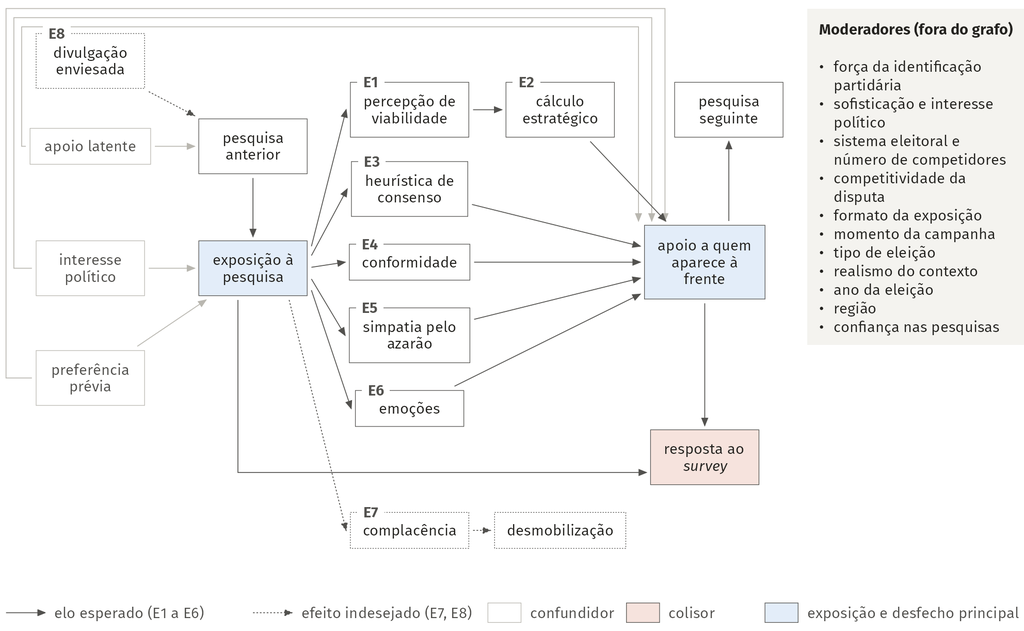

Figura 1: Modelo lógico da exposição a pesquisas eleitorais publicadas, redesenhado a partir do grafo acíclico dirigido do protocolo. A percepção de viabilidade (E1) só chega ao apoio pelo cálculo estratégico (E2). Heurística de consenso, conformidade, simpatia pelo azarão e emoções (E3 a E6) saem direto da exposição, embora, na teoria, a heurística de consenso e a conformidade dependam da percepção de popularidade. Complacência e divulgação enviesada (E7 e E8) são efeitos não intencionais e aparecem em tracejado. No comparecimento, o modelo não inclui a pivotalidade, o efeito Titanic nem a mobilização de quem está atrás. Apoio latente, interesse político e preferência prévia são confundidores (em cinza). A resposta ao *survey* é um colisor: condicionar a análise a ela abre um caminho espúrio entre exposição e apoio. A recorrência entre pesquisas e voto aparece desdobrada no tempo (pesquisa anterior e pesquisa seguinte). Os moderadores da teoria ficam fora do grafo, no quadro à direita. Aprovamos no G2 o modelo, proposto por IA, e nenhuma seta foi conferida em texto completo.

No comparecimento, o modelo tem só a complacência e deixa de fora canais que a literatura usa para prever o sinal: (i) a pivotalidade, em que a disputa apertada mobiliza e a folgada desmobiliza; (ii) o efeito “Titanic”; e (iii) a mobilização de quem está atrás. Como esses canais têm sinais opostos conforme o que a pesquisa mostra e o lado do eleitor, a comparação entre ver e não ver pesquisa não tem sinal previsto. Trata-se de uma limitação do modelo e, portanto, desta síntese.

No alvo principal – isto é, o apoio a quem a pesquisa mostra à frente –, o *bandwagon* prevê estimativa positiva, e o *underdog*, negativa. O voto estratégico aparece na viabilidade, mas cai no alvo principal quando a opção viável é o próprio líder; o *bandwagon* dinâmico, por sua vez, aparece no *momentum*. O protocolo registrou ainda três teorias rivais: (i) efeitos que se anulam no agregado; (ii) efeito só sobre a expectativa, e não sobre o voto; e (iii) efeito artefatual, maior em laboratório e vinheta que em eleição real. O Quadro 1 resume os termos.

Quadro 1: Glossário e como ler esta síntese.

| Termo | Como é usado nesta síntese |
| --- | --- |
| Como ler | A síntese não estima o tamanho do efeito. Ela conta em que direção apontam os estudos de cada célula, e a certeza GRADE qualifica essa direção, e não a magnitude. |
| Exposição | Contato com resultado de pesquisa eleitoral em quatro formatos: pesquisa pré-eleitoral; agregador ou projeção; pesquisa de boca de urna (levantamento feito no dia da votação, e não o crime eleitoral d… |
| *Bandwagon* e *underdog* | Na síntese, rótulo operacional da estimativa positiva (*bandwagon*) ou negativa (*underdog*) no apoio a quem a pesquisa mostra à frente, no alvo principal. A direção *bandwagon* é compatível com adesã… |
| Alvo do efeito | Quinta dimensão da célula, fixada pela Emenda 5 depois de ver os dados. Na tipologia de Barnfield (2020), o alvo principal é conversão estática, o *momentum* é conversão dinâmica e a mobilização é mob… |
| Viabilidade | Efeito sobre opções mostradas como viáveis ou inviáveis (segundo colocado viável, terceiro sem chance, partido perto da cláusula de barreira). Positivo quer dizer deserção para a opção viável. |
| *Momentum* | Pesquisa que mostra um partido ganhando ou perdendo apoio sem mostrar sua posição (Emenda 4b). Positivo quer dizer a favor de quem ganha apoio. |
| Mobilização e desmobilização | Efeito sobre o comparecimento ou a intenção de comparecer. Positivo quer dizer mobilização, e negativo, desmobilização. A teoria prevê os dois sinais, conforme o canal (pivotalidade, complacência, efe… |
| Célula | Formato de exposição × desfecho × comparador × alvo × classe de desenho. Estudos randomizados e não randomizados nunca se juntam. |
| Direção e “x de y” | x estudos na direção positiva entre os y com direção definida. Estudos nulos e mistos ficam fora do denominador. A direção vem da estimativa pontual, nunca da significância. Um estudo com vários efeit… |
| δ e nulo por ±δ | δ vale 2 pontos percentuais, isto é, 2 em cada 100 eleitores, convertidos em g: 0,044 no apoio e 0,046 no comparecimento, com a proporção de referência padrão, e 0,0573 na célula principal de apoio co… |
| Fora da contagem | Efeitos principais que não estimam o contraste da exposição (interações com moderadores contínuos, contrastes de formato da mesma previsão, alvos opostos somados) ou que ficaram fora num ponto de julg… |
| Certeza (GRADE) | ⊕⊕⊕⊕ alta, ⊕⊕⊕◯ moderada, ⊕⊕◯◯ baixa e ⊕◯◯◯ muito baixa, com as frases “provavelmente” (moderada), “pode” (baixa) e “a evidência é muito incerta sobre” (muito baixa). |
| Estudo e relato | Um estudo pode ter vários relatos (artigo, *working paper*, tese). |

## 1.3 Por que esta síntese

Hardmeier (2008) é um capítulo de síntese que, sem texto aberto, não verificamos. Moy e Rinke (2012), numa revisão narrativa sem método de seleção descrito, concluem que a literatura não permitia dizer se o *bandwagon* ou o *underdog* era mais comum. Barnfield (2020) é uma revisão conceitual, e Coşgun (2026), uma revisão sistemática sobre campanhas, numa só base e só em inglês. A checagem de 19/09/2026 (OpenAlex, OSF Registries e BDTD) não achou revisão sistemática ou meta-análise do tema posterior a 2008, nem revisão registrada em andamento.

Esta síntese faz três contribuições: (i) um inventário, com protocolo congelado e busca documentada, da evidência causal publicada desde 2010; (ii) células que nunca juntam sorteio com observação e isolam o *momentum* e a deserção para o segundo colocado viável; e (iii) uma leitura dirigida ao debate brasileiro. Foi conduzida com agentes de IA, e o risco de viés e a certeza não tiveram validação humana (Seção 2.9).

## 1.4 Objetivos

A pergunta principal do protocolo é: “A exposição a resultados de pesquisas eleitorais publicadas altera a intenção ou a escolha de voto do eleitorado, em comparação com a não exposição ou com a exposição a outro resultado, e em que direção (*bandwagon* ou *underdog*)?” As perguntas secundárias são se ela reduz o comparecimento, por quais mecanismos, para quem, onde e quando, e se os achados diferem entre Brasil e América Latina e as demais regiões.

De forma antecipada, nos experimentos as estimativas apontaram a favor de quem aparece à frente, mas a evidência é muito incerta. Pesquisa apertada, em vez de folgada, provavelmente não muda o comparecimento além de 2 pontos percentuais (certeza moderada). Nesta busca, sem a SciELO, o único estudo brasileiro trata de apuração parcial, e não de pesquisa.

# 2 Métodos

## 2.1 Protocolo, tipo de síntese e desvios

Aprovamos o protocolo no portão G2, em 19/09/2026, e a ferramenta o congelou com *hash* no *log*, mas, sem registro público anterior à busca, o leitor não confere quando cada decisão foi fixada. Trata-se de uma síntese de efetividade sem meta-análise (SWiM), na variante rápida (Lamarca 2026), relatada pelo PRISMA 2020 (Page, McKenzie, et al. 2021; Page, Moher, et al. 2021), pelo PRISMA-S (Rethlefsen et al. 2021) e pelo SWiM (Campbell et al. 2020), com o PRISMA-trAIce (Holst et al. 2025) só como lista de conferência. O protocolo, as emendas e as listas preenchidas estão no pacote de replicação.

Optamos pela variante rápida sem prazo externo nem consulta a *stakeholders*. A diretriz de revisões rápidas (Garritty et al. 2024), no entanto, aconselha que elas sejam “led only by experienced systematic reviewers”, e esta síntese foi conduzida por agentes. Frente à diretriz, (i) as fontes restritas (A1) atendem à recomendação 5 só na forma, porque a BDTD é catálogo de teses; (ii) triagem, risco de viés e certeza só por agentes (A2) não correspondem a atalho aceito, porque as recomendações 9, 16 e 23 pedem uma segunda pessoa; e (iii) a pré-revisão PRESS (*Peer Review of Electronic Search Strategies*) por IA (A4), que conferimos, atende à recomendação 6 só na forma mínima (Apêndice B).

As contingências E001 e E002 foram acionadas antes da triagem, e a Emenda 3 veio antes de qualquer avaliação de risco de viés. Já as Emendas 1, 2 (decidida pelo coordenador de IA e endossada por nós), 4, 5, 6b, 7 e 8 vieram depois de ver dados, com os detalhes nas Informações adicionais e no Apêndice B.

## 2.2 Critérios de elegibilidade

Os critérios, resumidos no Quadro 2, foram população e contexto (C1), exposição estudada como objeto empírico (C2), desfecho de voto ou de comparecimento (C3), desenho experimental, experimento natural, quase-experimento com variação identificada ou painel individual com exposição medida antes do desfecho (C4), estudo primário (C5) e ausência de retratação (C6). Ficaram de fora a percepção autodeclarada de influência, simulações, estudos agregados sem variação identificada e os que usam a pesquisa só como fonte de dados. Aceitamos relatos publicados desde 01/01/2010, em qualquer idioma e status de publicação, e, como aplicamos o corte ao ano de publicação, entraram estudos com dados anteriores. Texto não obtido ficou como não recuperado, nunca como excluído.

Quadro 2: Pergunta e critérios no formato PICOC (protocolo, seções 2 e 4).

| Elemento | Definição |
| --- | --- |
| População (P) | Eleitores ou participantes que escolhem entre candidatos, partidos ou opções de referendo, em eleição real, hipotética ou de laboratório (inclusive com preferências induzidas), em qualquer país; unida… |
| Exposição (I) | Contato com resultado de pesquisa eleitoral, em três formatos: pesquisa pré-eleitoral, agregador ou projeção e pesquisa de boca de urna divulgada antes do fechamento das urnas; pela Emenda 1, decidida… |
| Comparador (C) | Nenhuma pesquisa; o mesmo candidato mostrado atrás; outro resultado de pesquisa; antes e depois de uma proibição; unidades não expostas |
| Desfechos (O) | Apoio a quem a pesquisa mostra à frente (intenção de voto, escolha declarada ou incentivada, votação agregada), com sinal positivo para *bandwagon*; comparecimento (declarado, validado, agregado ou in… |
| Contexto (Co) | Estudos primários publicados desde 2010 (ano do OpenAlex e ano de defesa na BDTD), em qualquer idioma; Brasil e América Latina marcados para a análise regional |

## 2.3 Fontes e busca

Em 19/09/2026, a busca no OpenAlex usou título e resumo, com três estratégias: inglês (B05, 1.438 registros), português (B02, 118) e espanhol (B03, 131); na BDTD, usou todos os campos (B04, 80). A B01 foi substituída pela B05 (E002), e seus 1.235 registros ficaram fora dos identificados. A busca por citação no OpenAlex, para trás e para frente, teve três rodadas: SN1 (38 sementes, 1.189 registros, 19/09/2026), SN2 (12, 411, 20/09/2026) e SN3 (3, 106, 20/09/2026). Não buscamos na Web of Science, na Scopus ou na SciELO, em sites de literatura cinzenta nem em registros de estudos. As estratégias estão no Apêndice A.

Das 19 âncoras de validação, montadas por subagente isolado (A3), a v4 da estratégia em inglês recuperou 15, e a v5, 19. Como as 4 perdidas orientaram a correção, esse *recall* não é evidência independente. Não houve âncora em português ou espanhol. Em 23/09/2026, uma pré-revisão PRESS por IA da v5 apontou lacunas não corrigidas: faltam termos de proibição, embargo e apuração parcial (Lago, Guinjoan e Bermúdez 2015; Araujo e Gatto 2021a, só vieram pela busca por citação), e o fio de comparecimento é estreito. Conferimos essa pré-revisão e aceitamos a v5 com as lacunas declaradas (Emenda 7), o que não equivale a uma revisão PRESS independente.

## 2.4 Seleção dos estudos

Antes da triagem, *scripts* removeram os duplicados e os relatos publicados antes de 2010. Nos 145 pares candidatos a duplicata, concordamos com as sugestões da IA, e as decisões foram aplicadas depois da triagem (Emenda 8); nos 44 registros já triados que a fusão absorveu, valeu a decisão mais inclusiva, e os incluídos não mudaram.

Na triagem de títulos e resumos, dois triadores de IA independentes (A = `claude-sonnet-5`; B = `claude-opus-5`) aplicaram a regra liberal, em que bastava um incluir ou marcar incerto para o registro seguir. Por essa regra, as 81 divergências seguiram ao texto completo, e mantivemos esse estado. A concordância A × B na primeira onda foi de 0,97 (κ 0,90; PABAK 0,94), o que mede consistência, e não acurácia. Já o *recall* não foi calculado, porque as amostras de validação (141 registros) e de elusão (300) não foram codificadas às cegas por humanos.

Pela Emenda 6b, antes da deduplicação, dois agentes de IA triaram de novo os 336 registros sem resumo, que só saíam se ambos excluíssem: saíram 156, e 180 seguiram ao texto completo, onde 15 foram excluídos e 165 ficaram como não recuperados. Dispensamos a conferência dessa etapa.

No texto completo, um subagente por PDF propôs a elegibilidade, com trecho literal conferido por *script*. Os 184 relatos avaliados somam 165 propostas da IA (47 inclusões e 118 exclusões), que conferimos em bloco e mantivemos, 16 casos limítrofes que decidimos (8 inclusões e 8 exclusões) e 3 exclusões em que a IA estendeu uma regra nossa a caso novo, que endossamos (Emenda 7). Relatos do mesmo estudo foram ligados antes da extração. Nenhum PDF veio de Sci-Hub ou de outra fonte não autorizada.

## 2.5 Extração

O piloto com três estudos (Araujo e Gatto 2021a; Klor e Winter 2017; van der Meer, Hakhverdian e Aaldering 2015) levou à Emenda 2, e o conferimos em bloco. Um subagente `claude-opus-5` por texto preencheu a ficha, com trecho e página conferidos por *script*, e extraiu 560 efeitos de 40 estudos, sem contato com autores (A5). O modelo principal saiu de regra escrita antes, e nunca do menor valor-p.

Antes da síntese, um subagente `claude-opus-5-5` reextraiu às cegas os 56 efeitos principais de então: 15 concordaram, 23 tinham o mesmo valor com outra classificação, 12 outro valor e 6 outro sinal. Um árbitro de IA do mesmo modelo decidiu os 28 estudos com divergência, e o coordenador aplicou 772 correções, 240 delas estendidas sem nova arbitragem. Conferimos em bloco, na página do PDF, os 560 efeitos (Emenda 7).

Usamos o g de Hedges como métrica comum (efeitos individuais no Apêndice E). Convertemos proporções, pontos percentuais e razões de chances por d = ln(OR)·√3/π, e o logit que não relatou efeito marginal, por OR = exp(β). O probit na mesma situação e os estudos sem t, β ou r entraram só pela direção. Nos conglomerados sem ICC relatado, imputamos 0,05 (Emenda 4c), com sensibilidade em 0,20.

## 2.6 Risco de viés

Experimentos randomizados foram avaliados com o RoB 2, inclusive na variante por conglomerado (Sterne et al. 2019), e experimentos naturais, quase-experimentos e painéis, com o ROBINS-I V2, versão provisória (Sterne et al. 2016; Sterne, Higgins e ROBINS-I V2 development group 2025), no lugar do ROBINS-E, que os *scripts* não traziam. Proibições e embargos com unidades agregadas tiveram os critérios EPOC (Cochrane Effective Practice and Organisation of Care (EPOC) 2017), sem sequência e ocultação no julgamento geral (Emenda 4a). Dois avaliadores de IA independentes (A = `claude-opus-5-5`; B = `claude-sonnet-5`) julgaram cada resultado, e um árbitro de IA do mesmo modelo de A, que escolhemos por custo, decidiu os desacordos. Nenhum julgamento foi validado por humano, e declaramos esta etapa como feita só por IA nesta versão (Emenda 7). Os resultados em risco crítico saíram da análise principal.

## 2.7 Métodos de síntese

A unidade da síntese é a célula: formato de exposição × desfecho × comparador × alvo × classe de desenho. Randomizados e não randomizados nunca se juntaram, e contrastes antes e depois no mesmo sujeito foram à classe não randomizada. O alvo, fixado pela Emenda 5 depois da primeira síntese, isola o *momentum* e a deserção para o segundo colocado viável, mas não a deserção para o próprio líder (Quadro 1).

O estimando segue a regra congelada do *codebook*. Nos randomizados, é o efeito causal da designação ao tratamento (ATE, ou ITT quando o estudo discute adesão imperfeita). Na diferença-em-diferenças sem sorteio, é o efeito nos tratados (ATT). No antes e depois só nos tratados, na interação com moderador não sorteado e na regressão com variáveis de controle, é uma associação. Como os estimandos diferem, as classes só se comparam pela direção.

O sinal segue o alvo e, nas proibições (Chatterjee e Kamal 2019; Morton et al. 2015), foi reorientado para a exposição. A direção veio da estimativa pontual, nunca da significância (Boon e Thomson 2021), e estudo com vários efeitos só teve direção com 70% deles do mesmo lado. Por célula, calculamos a proporção na direção positiva, com IC 95% exato de Clopper-Pearson (Clopper e Pearson 1934), e o teste de sinal binomial exato bilateral (Nikolakopoulos 2020). O teste de sinal não informa a magnitude, e, com poucos estudos pequenos, p acima de 0,05 não indica ausência de efeito.

O δ de 2 pontos percentuais, fixado no protocolo sem *benchmark*, virou g pela razão de chances: 0,044 no apoio e 0,046 no comparecimento, com a proporção de referência padrão, e 0,0573 na célula principal de apoio com pesquisa frente a nenhuma pesquisa (randomizados), com a mediana da proporção do grupo de comparação dos seus estudos; a Emenda 5 fixou os dois primeiros em vez do δ por célula que o protocolo pede. Pela Emenda 5, posterior aos dados, efeito com IC 95% dentro de ±δ virou nulo, e os efeitos principais que não estimam o contraste da exposição saíram da contagem (Apêndice E).

Nas duas células com 3 estudos com g, a meta-análise exploratória usou CHE (REML), variância robusta CR2, graus de liberdade de Satterthwaite e ρ = 0,6 (sensibilidade em 0,2, 0,5 e 0,8) (Pustejovsky e Tipton 2022), no metafor 5.0.1 (Viechtbauer 2010) e no clubSandwich 0.7.0 (Pustejovsky 2026), em R 4.5.2. Menos de 4 graus de liberdade tornam a inferência robusta não confiável, e não houve IC de Wald nem de HKSJ. Com k < 5, não interpretamos τ², I² nem o intervalo de predição.

Os moderadores ficaram descritivos, sem 3 estudos por nível em nenhuma célula. As sensibilidades foram (i) nas células, com os críticos e ICC de 0,20; (ii) no agrupamento amplo, *post hoc*, só com contexto real, sem dados anteriores a 2010, sem Araujo e Gatto (2021a) e com os efeitos fora da contagem; e (iii) nas metas, *leave-one-out*, ρ e ICC. O viés por resultados faltantes entrou no GRADE, sem teste de assimetria (k < 10). Não houve síntese de percepção, implementação ou custo, dimensões que não se aplicam a um fenômeno de informação sem gestor que o implemente.

## 2.8 Certeza da evidência

A certeza foi julgada pelo GRADE, por célula (Guyatt et al. 2008), com os domínios adaptados para síntese sem meta-análise (Murad et al. 2017). Randomizados e não randomizados avaliados com ROBINS-I V2 partiram de alta, estes com rebaixamento por risco de viés, e corpos com EPOC, de baixa. A indireção considerou contexto eleitoral, realismo e estimando, e a imprecisão, número de estudos e de participantes e largura do IC da proporção. O limiar do juízo é zero para a direção e ±δ para a célula nula. Um subagente (`claude-opus-5-5`) julgou a certeza em 24/09/2026, sem segundo avaliador, e o juízo não foi validado por humano (Emenda 7). Cada rebaixamento foi justificado por escrito, e os enunciados usam as frases padronizadas (Santesso et al. 2020).

Não relatamos a caixa de ferramentas no formato *O que funciona?* (Schaefer, Borges e Freitas 2025), opcional neste tipo de síntese, porque, com certeza muito baixa em 15 das 18 células e o GRADE não validado, nenhuma célula teria rótulo definido (Emenda 7).

## 2.9 Uso de IA e conferência humana

Um coordenador de IA (`claude-opus-5-5`) rodou a ferramenta de revisão no Claude Code e distribuiu o trabalho entre subagentes, cujos modelos por etapa estão nas seções 2.4 a 2.8 e no Apêndice G. Fomos os únicos humanos do processo: aprovamos a pergunta e o protocolo (portões G1 e G2), decidimos as Emendas 1, 4 (itens 4a a 4c) e 6b e 16 casos limítrofes de elegibilidade, e escolhemos por custo o árbitro do risco de viés.

Revisamos o trabalho dos agentes nos portões G3 (busca), G5 (elegibilidade no texto completo) e G6 (piloto de extração), e aprovamos o relato no portão G9. Nos portões G4 (triagem) e G7 (extração e risco de viés), a revisão foi parcial: conferimos as divergências da triagem e os efeitos extraídos, mas a validação cega da triagem não foi feita, e o risco de viés segue sem validação humana. No G8, da síntese e da certeza da evidência, o juízo de certeza também ficou só com a IA.

Em 30/09/2026, revimos e aprovamos juntos, em bloco, as decisões em vigor sobre: (i) a busca, pela conferência da pré-revisão PRESS por IA, que não é uma revisão PRESS independente; (ii) as 81 divergências da triagem, mantidas no texto completo pela regra liberal; (iii) a elegibilidade, com as 165 propostas da IA e as 3 extensões de regra; (iv) o piloto de extração; (v) os 560 efeitos, contra a página do PDF; (vi) as 259 divergências da recodificação, mantido o valor original; e (vii) o relato da versão de 24/09/2026. Aprovamos também o conteúdo desta versão, já com a Emenda 8, antes da entrega. Nenhuma decisão em vigor, dado de efeito ou contagem mudou (Emenda 7). As lacunas por etapa estão no Apêndice G, e a declaração de uso de IA, nas Informações adicionais.

# 3 Resultados

## 3.1 Estudos incluídos

A busca identificou 1.767 registros nas bases e 1.706 pela busca por citação. Na deduplicação e no filtro de ano, saíram 91 e 17 duplicados e 143 e 639 relatos (bases e outros métodos), e, dos 1.533 e 1.050 registros triados, os triadores de IA excluíram 1.277 e 784. Não foram recuperados 155 dos 256 e 183 dos 266 relatos buscados (338 de 522). Dos 101 e 83 avaliados, 59 e 70 foram excluídos, sobretudo por exposição fora do critério C2 (39 e 50). Foram incluídos 41 estudos, em 55 relatos, 42 das bases e 13 dos outros métodos (Figura 2).

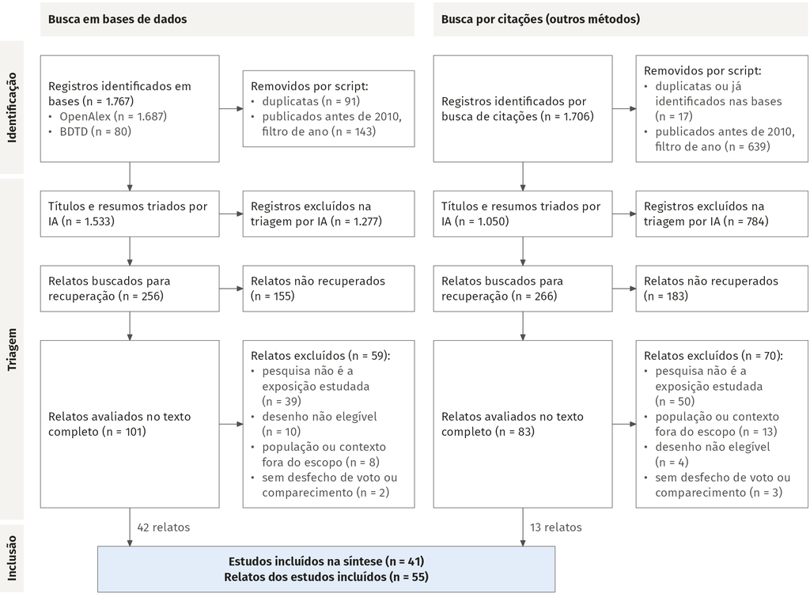

Figura 2: Fluxo PRISMA 2020 da seleção, com os dois ramos de identificação (bases de dados e busca por citações). A remoção de duplicatas e o filtro de ano de publicação foram feitos por script; nos 145 pares incertos, concordamos com as sugestões da IA, e essas fusões (58 registros, 44 já triados) foram aplicadas depois da triagem (Emenda 8). A triagem de títulos e resumos ficou com agentes de IA, assim como a avaliação dos textos completos, que conferimos em bloco (Emenda 7), exceto 16 casos limítrofes decididos por nós (8 inclusões e 8 exclusões). A triagem complementar da Emenda 6b entra no fluxo sem ramo próprio, e os relatos dela que não foram recuperados estão entre os não recuperados. As caixas do modelo PRISMA que não se aplicam a esta síntese (n = 0) foram omitidas. Os motivos de exclusão seguem os critérios de elegibilidade do protocolo, e os relatos sem cópia legítima acessível contam como não recuperados. Nos 44 registros já triados que as fusões absorveram, o registro que absorveu ficou com a decisão mais inclusiva do par, e os estudos incluídos não mudaram (Apêndice G).

Pareciam elegíveis e foram excluídos jogos de laboratório com contagem de votos ou placar no lugar da pesquisa (Bischoff e Egbert 2013; Hizen et al. 2025; Morton e Ou 2015; Scheuerman et al. 2019, 2020, 2021; Yosef et al. 2017, C2), um experimento natural no Peru que juntava boca de urna e contagem parcial (Plaza 2026, C2), um artigo que não analisa o experimento citado (Corbetta e Colloca 2013, C2), um estudo de efeito de terceira pessoa (H. J. Kim 2018, C3), jogos em equipe (J. Kim e Palfrey 2026, C1) e estudos com a pesquisa como medida agregada (Fredén 2021; Mavridis 2016, C4) (lista com o critério e quem decidiu no Apêndice C).

Publicados de 2010 a 2024, os estudos são sobretudo experimentos de *survey* (14) e de laboratório com preferências induzidas (9). A exposição é pesquisa pré-eleitoral em 33, e o contexto é real em 25; quanto ao desfecho, 24 medem só o apoio, 10 só o comparecimento e 7 os dois. Exceto 1 estudo do Brasil, 1 do México e 1 multinacional com o Brasil, os estudos vêm sobretudo dos Estados Unidos e da Europa (Tabela 1; estudo a estudo no Apêndice C).

Tabela 1: Características dos 41 estudos incluídos. n (%) de estudos; no risco de viés, n (%) de resultados avaliados com cada ferramenta (43 resultados de 37 estudos; os julgamentos de IA não foram validados por humano). “Outros desenhos”: painel de distritos, campanha simulada, corte transversal de países, desenho múltiplo e *rolling cross-section*. Estudo a estudo nos Apêndices C e D.

| Característica | n (%) |
| --- | --- |
| **Desenho** |  |
| experimento de *survey* | 14 (34,1) |
| laboratório, preferências induzidas | 9 (22,0) |
| experimento natural | 6 (14,6) |
| outros desenhos | 5 (12,2) |
| laboratório, candidatos reais | 3 (7,3) |
| painel individual | 3 (7,3) |
| experimento de campo | 1 (2,4) |
| **Formato da exposição** |  |
| pesquisa pré-eleitoral | 33 (80,5) |
| agregador ou projeção | 4 (9,8) |
| boca de urna antes do fechamento | 3 (7,3) |
| apuração parcial oficial | 1 (2,4) |
| **Realismo do contexto** |  |
| eleição real | 25 (61,0) |
| preferências induzidas em laboratório | 9 (22,0) |
| eleição hipotética (vinheta) | 7 (17,1) |
| **Região** |  |
| fora da América Latina | 37 (90,2) |
| Brasil | 1 (2,4) |
| América Latina (sem o Brasil) | 1 (2,4) |
| multinacional, com Brasil e América Latina | 1 (2,4) |
| não informada | 1 (2,4) |
| **Tipo de eleição** |  |
| candidatos ou partidos | 32 (78,0) |
| simulada, abstrata | 8 (19,5) |
| referendo | 1 (2,4) |
| **Desfechos extraídos** |  |
| só apoio a quem aparece à frente | 24 (58,5) |
| só comparecimento | 10 (24,4) |
| os dois | 7 (17,1) |
| **Ano de publicação (relato principal)** |  |
| 2010 a 2014 | 5 (12,2) |
| 2015 a 2019 | 19 (46,3) |
| 2020 a 2024 | 17 (41,5) |
| **Risco de viés geral, RoB 2 (23 resultados randomizados)** |  |
| algumas preocupações | 17 (73,9) |
| alto | 6 (26,1) |
| **Risco de viés geral, ROBINS-I V2 (13 resultados)** |  |
| grave | 8 (61,5) |
| crítico | 3 (23,1) |
| moderado | 2 (15,4) |
| **Risco de viés geral, EPOC (7 resultados)** |  |
| alto | 6 (85,7) |
| baixo | 1 (14,3) |

Dos 41 estudos, 27 entram na síntese principal, e os outros 14, só nos mecanismos, nos moderadores e nas sensibilidades: (i) 3 estão em risco de viés crítico (Gasperoni e Mantovani 2015, também fora da contagem; Kaplan 2019; Unkelbach, John e Vogel 2022); (ii) 7 têm todos os efeitos principais fora da contagem (Alabrese e Fetzer 2024; Bursztyn et al. 2023; Gandhi e Ong 2019; Geers, Bos e de Vreese 2018; Lago, Guinjoan e Bermúdez 2015; Meffert e Gschwend 2011; Urminsky e Shen 2019); e (iii) 4 não têm efeito principal extraído (Fredén 2016, cujo PDF é só o capítulo introdutório da tese; Meffert e Gschwend 2012; Tyszler e Schram 2013; Yang et al. 2023).

## 3.2 Risco de viés nos estudos

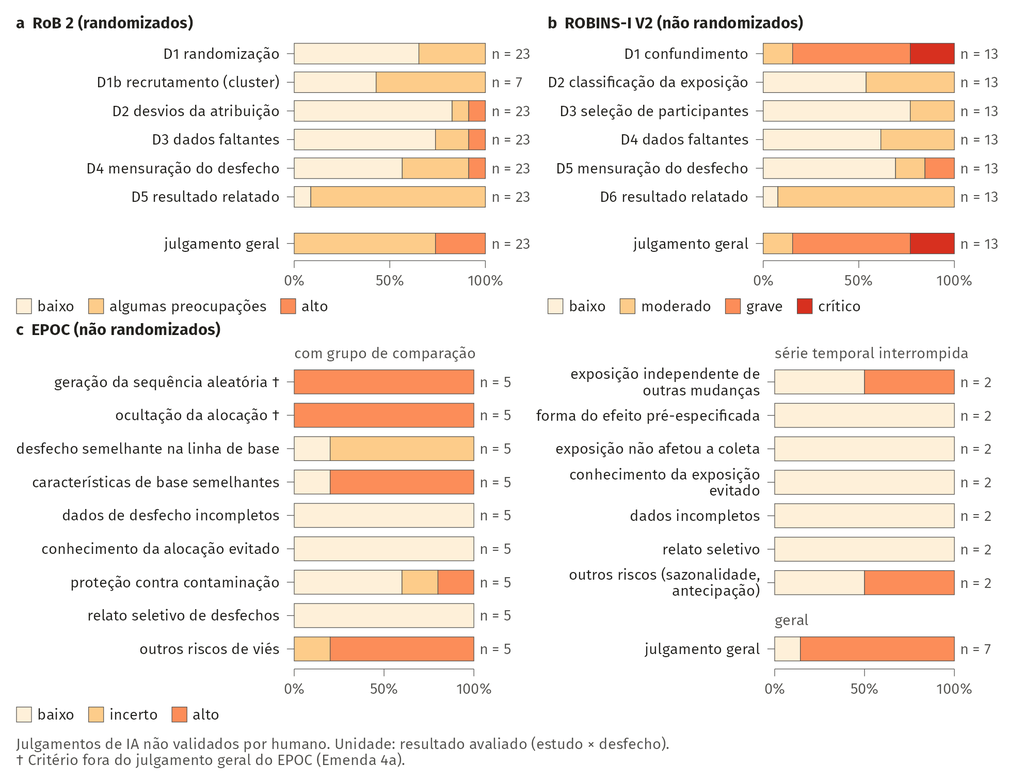

Figura 3: Risco de viés por ferramenta e domínio, em proporção dos resultados avaliados (cada resultado é um par estudo × desfecho). O painel **a** usa o RoB 2, nos estudos randomizados; o **b**, o ROBINS-I V2, nos não randomizados; e o **c**, os critérios EPOC, nos desenhos com grupo de comparação ou série temporal interrompida. São 43 resultados de 37 estudos. O domínio D1b só se aplica à randomização por conglomerado. Os julgamentos são o consenso proposto por agentes de IA (dois avaliadores e um árbitro nas divergências), sem validação humana. As cores seguem a paleta para daltonismo do robvis.

## 3.3 Visão geral da síntese

Dos 41 estudos, 40 têm efeitos extraídos (560 no total), e 37 têm ao menos um efeito principal. A síntese principal reúne 27 estudos em 18 células, com n de 12 eleitorados de laboratório a 453.016 seções eleitorais. A célula não randomizada de projeções frente a nenhuma pesquisa no comparecimento ficou vazia com a exclusão de Kaplan (2019), em risco crítico. No GRADE, julgado só por IA, 15 das 18 células ficaram com certeza muito baixa, 2 com baixa e 1 com moderada.

A Figura 4 mostra a direção de cada estudo, ordenada por célula, desenho e risco de viés (efeitos individuais no Apêndice E). Nenhuma célula passa de 4 estudos. Mesmo 4 de 4 na mesma direção dão p = 0,125, que não indica ausência de efeito, e p < 0,05 exigiria pelo menos 6.

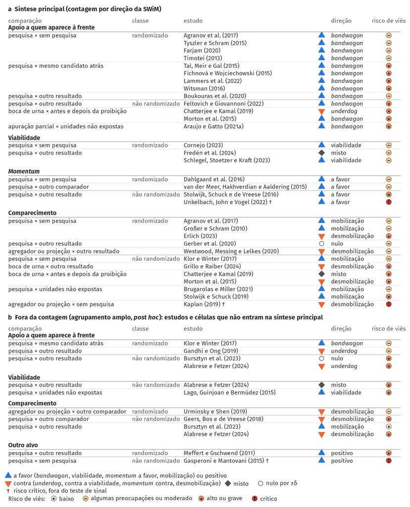

Figura 4: Direção do efeito principal por estudo e célula. No painel **a**, da síntese principal, os estudos estão agrupados por desfecho, classe de desenho e comparação e ordenados por desenho e risco de viés. Os de risco crítico (†) aparecem, mas ficam fora do teste de sinal. O painel **b** traz os efeitos fora da contagem, no agrupamento amplo decidido depois de ver os dados (*post hoc*). Ali entram só estudos e células que não estão na síntese principal, seja porque o efeito principal não estima o contraste da exposição, seja por risco crítico ou por alvo sem posição única de líder ou azarão (“outro alvo”, em que o sinal é só positivo ou negativo). A direção vem do estimador pontual, e o efeito é nulo quando o intervalo de 95% fica inteiro dentro de ±δ. O risco de viés segue a Figura 3, com julgamentos de IA.

## 3.4 Apoio a quem aparece à frente

Quatro experimentos compararam ver uma pesquisa com não ver (Agranov et al. 2017; Farjam 2020; Timotei 2013; Tyszler e Schram 2015), todos com algumas preocupações de risco de viés. Farjam (2020), o único em contexto real, é uma votação *online* sobre organizações políticas reais, sem eleição em curso; já em Agranov et al. (2017) e Tyszler e Schram (2015), o desfecho é a eleição do grupo, e não o voto individual. A proporção ficou em 1,00 (IC 95% 0,40 a 1,00; p = 0,125). A evidência é muito incerta sobre se ver pesquisa que mostra quem está à frente, frente a não ver pesquisa, aumenta o apoio ao líder (4 de 4 estudos na direção *bandwagon*, 3 deles de laboratório ou vinheta; certeza muito baixa).

Há, no entanto, outra leitura para Tyszler e Schram (2015) e Agranov et al. (2017): o primeiro trata a informação como coordenação estratégica entre três opções, e, no segundo, com pesquisa, a maioria vota mais e a minoria, menos. Nos jogos com preferências induzidas, em que o experimento fixa o pagamento do voto, a falta de *underdog* é, em parte, construção do desenho.

Tabela 2: Resumo dos achados por célula da síntese principal (SWiM, sem os estudos em risco de viés crítico). Direção: x de y = estudos na direção indicada entre os y que têm direção definida; estudos mistos e nulos por ±δ ficam fora do denominador; proporção com IC 95% de Clopper-Pearson. Certeza GRADE: ⊕⊕⊕⊕ alta, ⊕⊕⊕◯ moderada, ⊕⊕◯◯ baixa, ⊕◯◯◯ muito baixa; ela qualifica a direção, não a magnitude, e foi julgada só por IA, sem validação humana. n na unidade de cada estudo, quando a unidade está registrada; os n não são somados. O agrupamento amplo, decidido depois de ver os dados, fica fora desta tabela (Apêndice F).

| Comparação e desenho | Estudos (k; n do efeito principal) | Direção (x de y com direção definida) | Certeza | O que a evidência diz | Notas |
| --- | --- | --- | --- | --- | --- |
| **Apoio a quem aparece à frente** |  |  |  |  |  |
| Pesquisa pré-eleitoral, frente a nenhuma pesquisa (randomizados) | 4 estudos: Agranov et al. (2017), n = 300 eleições de grupo; Farjam (2020), n = 1.113 participantes; Timotei (2013), n = 80 respondentes; Tyszler e Schram (2015), n = 12 eleitorados | 4 de 4 na direção *bandwagon* (proporção 1,00; IC 95% 0,40 a 1,00) | ⊕◯◯◯ muito baixa | A evidência é muito incerta sobre se ver pesquisa que mostra quem está à frente, frente a não ver pesquisa, aumenta o apoio ao líder (4 de 4 estudos na direção *bandwagon*, 3 deles de laboratório ou v… | a, d, e, g |
| Pesquisa pré-eleitoral, candidato mostrado à frente, frente ao mesmo candidato mostrado atrás (randomizados) | 4 estudos: Tal, Meir e Gal (2015), n não relatado; Lammers et al. (2022), n = 100; Fichnová e Wojciechowski (2015), n = 24 respondentes; Witsman (2016), n = 142 | 4 de 4 na direção *bandwagon* (proporção 1,00; IC 95% 0,40 a 1,00) | ⊕◯◯◯ muito baixa | A evidência é muito incerta sobre se ver o candidato à frente numa pesquisa, em vez de atrás, aumenta o apoio a ele (4 de 4 estudos na direção *bandwagon*, todos de laboratório ou vinheta e em risco d… | b, d, e, g |
| Pesquisa pré-eleitoral, frente a outro resultado de pesquisa (randomizados) | 1 estudo: Boukouras et al. (2020), n = 135 observações | 1 de 1 na direção *bandwagon* (proporção 1,00; IC 95% 0,03 a 1,00) | ⊕◯◯◯ muito baixa | A evidência é muito incerta sobre se revelar um conjunto de pesquisas diferente, da mesma eleição, aumenta a vitória do candidato à frente (1 estudo de laboratório, 3 de 3 efeitos na direção *bandwago… | d, f |
| Pesquisa pré-eleitoral, frente a outro resultado de pesquisa (não randomizados) | 1 estudo: Feltovich e Giovannoni (2022), n não relatado | 1 de 1 na direção *bandwagon* (proporção 1,00; IC 95% 0,03 a 1,00) | ⊕◯◯◯ muito baixa | A evidência é muito incerta sobre se ver uma prévia com maior parcela do incumbente aumenta o voto nele (1 estudo de laboratório, com contraste não sorteado; certeza muito baixa). | b, d, e |
| Boca de urna antes do fechamento das urnas, antes e depois da proibição (não randomizados) | 2 estudos: Morton et al. (2015), n = 60 observações; Chatterjee e Kamal (2019), n = 1.737 distritos | 1 de 2 na direção *bandwagon*, 1 *underdog* (proporção 0,50; IC 95% 0,01 a 0,99) | ⊕◯◯◯ muito baixa | A evidência é muito incerta sobre se a divulgação de boca de urna antes do fechamento das urnas aumenta ou reduz o apoio ao líder (2 estudos em direções opostas; certeza muito baixa). | a, c, d, e, h |
| Apuração parcial oficial, unidades expostas frente a não expostas (não randomizados) | 1 estudo: Araujo e Gatto (2021a), n = 453.016 seções eleitorais | 1 de 1 na direção *bandwagon* (proporção 1,00; IC 95% 0,03 a 1,00) | ⊕◯◯◯ muito baixa | A evidência é muito incerta sobre se a divulgação oficial de apuração parcial enquanto a votação continua aumenta o voto no candidato à frente (1 estudo brasileiro na direção *bandwagon*; certeza muit… | b, d, e |
| **Viabilidade: apoio à opção mostrada como viável** |  |  |  |  |  |
| Pesquisa pré-eleitoral, frente a nenhuma pesquisa (randomizados) | 1 estudo: Cornejo (2023), n = 545 respondentes | 1 de 1 na direção de viabilidade (proporção 1,00; IC 95% 0,03 a 1,00) | ⊕◯◯◯ muito baixa | A evidência é muito incerta sobre se ver pesquisa que mostra um candidato de oposição como segundo colocado viável aumenta o apoio a ele (1 estudo no México; certeza muito baixa). | a, f |
| Pesquisa pré-eleitoral, frente a outro resultado de pesquisa (randomizados) | 2 estudos: Schlegel, Stoetzer e Kraft (2023), n não relatado; Fredén et al. (2024), n = 744 respondentes | 1 de 1 na direção de viabilidade; 1 misto (proporção 1,00; IC 95% 0,03 a 1,00) | ⊕◯◯◯ muito baixa | A evidência é muito incerta sobre se pesquisas que mostram quais opções são viáveis levam eleitores a desertar para a opção viável (1 estudo a favor e 1 misto, com 2 de 3 efeitos contrários; certeza m… | a, c, d, e |
| *Momentum*: partido mostrado ganhando ou perdendo apoio |  |  |  |  |  |
| Pesquisa pré-eleitoral, frente a nenhuma pesquisa (randomizados) | 1 estudo: Dahlgaard et al. (2016), n = 1.700 respondentes | 1 de 1 a favor (proporção 1,00; IC 95% 0,03 a 1,00) | ⊕◯◯◯ muito baixa | A evidência é muito incerta sobre se ver pesquisa que mostra um partido ganhando apoio, frente a não ver pesquisa, aumenta o voto nele (*momentum*; 1 estudo; certeza muito baixa). | a, d, f |
| Pesquisa pré-eleitoral, frente a outra apresentação do resultado (randomizados) | 1 estudo: van der Meer, Hakhverdian e Aaldering (2015), n = 10.643 respondentes | 1 de 1 a favor (proporção 1,00; IC 95% 0,03 a 1,00) | ⊕◯◯◯ muito baixa | A evidência é muito incerta sobre se ver pesquisa que mostra um partido ganhando apoio aumenta o voto nele (*momentum*; 1 estudo; certeza muito baixa). | d, f |
| Pesquisa pré-eleitoral, frente a outro resultado de pesquisa (não randomizados) | 1 estudo: Stolwijk, Schuck e de Vreese (2016), n = 6.384 observações | 1 de 1 a favor (proporção 1,00; IC 95% 0,03 a 1,00) | ⊕◯◯◯ muito baixa | A evidência é muito incerta sobre se a cobertura de pesquisas favorável a um partido aumenta o voto nele (*momentum*; 1 estudo observacional; certeza muito baixa). | b, d, e |
| **Comparecimento** |  |  |  |  |  |
| Pesquisa pré-eleitoral, frente a nenhuma pesquisa (randomizados) | 3 estudos: Agranov et al. (2017), n = 135 observações; Großer e Schram (2010), n = 12 eleitorados; Erlich (2023), n = 181 participantes | 2 de 3 na direção de mobilização, 1 de desmobilização (proporção 0,67; IC 95% 0,09 a 0,99) | ⊕◯◯◯ muito baixa | A evidência é muito incerta sobre se ver pesquisa, frente a não ver, aumenta ou reduz o comparecimento (2 estudos de laboratório na direção de mobilização e 1 com candidatos reais na de desmobilização… | a, c, d, e |
| Pesquisa pré-eleitoral, frente a outro resultado de pesquisa (randomizados) | 1 estudo: Gerber et al. (2020), n = 126.126 pessoas | nenhum estudo com direção definida; 1 nulo por ±δ | ⊕⊕⊕◯ moderada | Receber pesquisa que mostra disputa apertada, em vez de folgada, provavelmente não muda o comparecimento além de 2 p.p. para mais ou para menos (efeito nulo ou trivial; 1 experimento de campo; certeza… | e |
| Agregador ou projeção, frente a outro resultado de pesquisa (randomizados) | 1 estudo: Westwood, Messing e Lelkes (2020), n = 5.845 decisões | 0 de 1 na direção de mobilização, 1 de desmobilização (proporção 0,00; IC 95% 0,00 a 0,98) | ⊕⊕◯◯ baixa | Ver projeções de agregador que mostram probabilidade de vitória mais distante de 50:50 pode reduzir a decisão de votar (direção de desmobilização; 1 estudo; certeza baixa). | d, e |
| Pesquisa pré-eleitoral, frente a nenhuma pesquisa (não randomizados) | 1 estudo: Klor e Winter (2017), n = 84 participantes | 1 de 1 na direção de mobilização (proporção 1,00; IC 95% 0,03 a 1,00) | ⊕◯◯◯ muito baixa | A evidência é muito incerta sobre se revelar a distribuição de preferências do eleitorado aumenta o comparecimento (1 estudo de laboratório, antes e depois no mesmo sujeito; certeza muito baixa). | a, d, e |
| Boca de urna antes do fechamento das urnas, frente a outro resultado de pesquisa (não randomizados) | 1 estudo: Grillo e Raiber (2024), n = 576 observações | 0 de 1 na direção de mobilização, 1 de desmobilização (proporção 0,00; IC 95% 0,00 a 0,98) | ⊕◯◯◯ muito baixa | A evidência é muito incerta sobre se a boca de urna divulgada mais cedo durante a votação reduz o comparecimento (1 estudo na direção de desmobilização, com IC que cruza zero; certeza muito baixa). | a, d, f, h |
| Boca de urna antes do fechamento das urnas, antes e depois da proibição (não randomizados) | 2 estudos: Morton et al. (2015), n = 1.260 observações; Chatterjee e Kamal (2019), n = 1.737 distritos | 0 de 1 na direção de mobilização, 1 de desmobilização; 1 misto (proporção 0,00; IC 95% 0,00 a 0,98) | ⊕◯◯◯ muito baixa | A evidência é muito incerta sobre se a divulgação de boca de urna antes do fechamento das urnas reduz o comparecimento (1 estudo na direção de desmobilização e 1 misto; certeza muito baixa). | a, c, d, e, h |
| Pesquisa pré-eleitoral, unidades expostas frente a não expostas (não randomizados) | 2 estudos: Stolwijk e Schuck (2019), n = 747 respondentes; Brugarolas e Miller (2021), n não relatado | 2 de 2 na direção de mobilização (proporção 1,00; IC 95% 0,16 a 1,00) | ⊕⊕◯◯ baixa | Ter visto a divulgação de pesquisas pode aumentar a intenção de votar ou o comparecimento (2 estudos observacionais em eleições reais, ambos na direção de mobilização; certeza baixa). | a, e |
| *Notas.* *a* Rebaixada 1 nível por risco de viés nos estudos da célula (RoB 2, ROBINS-I V2 ou EPOC). *b* Rebaixada 2 níveis por risco de viés nos estudos da célula (RoB 2, ROBINS-I V2 ou EPOC). *c* Re… |  |  |  |  |  |

A meta-análise exploratória dessa célula (Figura 5, painel a), com os três estudos que têm g (Agranov et al. 2017; Timotei 2013; Tyszler e Schram 2015) e 4 efeitos, deu g = 0,48 (IC 95% −1,51 a 2,47; p = 0,263), com 1,25 grau de liberdade e IC que cruza zero e ±δ (0,0573). τ², I² (15%) e o intervalo de predição não são interpretados. Com ρ de 0,2 a 0,8 e com ICC de 0,20, g ficou entre 0,47 e 0,51. No *leave-one-out*, o IC só deixou de cruzar zero sem Timotei (2013) (0,40 a 0,98).

Outros quatro experimentos compararam o mesmo candidato mostrado à frente ou atrás (Fichnová e Wojciechowski 2015; Lammers et al. 2022; Tal, Meir e Gal 2015; Witsman 2016), de novo com proporção 1,00 (IC 95% 0,40 a 1,00; p = 0,125). Tal, Meir e Gal (2015) mede também o compromisso estratégico pelo segundo preferido, e Witsman (2016) lê seu contraste como voto estratégico; lido como viabilidade, leitura possível e não adotada, esse efeito sairia da célula e da meta. Em Lammers et al. (2022), os sinais se opõem conforme o raciocínio induzido (g = 1,25 e 1,03 no modo heurístico; −0,39 e 0,06 no moral), e a direção *bandwagon* veio da regra de 70% (3 de 4 efeitos). A evidência é muito incerta sobre se ver o candidato à frente numa pesquisa, em vez de atrás, aumenta o apoio a ele (4 de 4 estudos na direção *bandwagon*, todos de laboratório ou vinheta e em risco de viés alto; certeza muito baixa).

A meta-análise dessa célula (Figura 5, painel b), com 3 estudos e 6 efeitos (Fichnová e Wojciechowski 2015; Lammers et al. 2022; Witsman 2016), deu g = 0,62 (IC 95% −0,48 a 1,72; p = 0,111), com 1,46 grau de liberdade e IC que cruza zero e ±δ (0,044), sobre desfechos pouco comparáveis. τ², I² (94%) e o intervalo de predição não são interpretados. O ρ quase não mudou g (0,61 a 0,62). No *leave-one-out*, o IC só deixou de cruzar zero sem Lammers et al. (2022) (0,85 a 0,94). Rodada depois do GRADE, esta meta não entrou no juízo de certeza. As duas meta-análises exploratórias, com 3 estudos cada e menos de 4 graus de liberdade, têm intervalos que cruzam zero e não informam o tamanho do efeito.

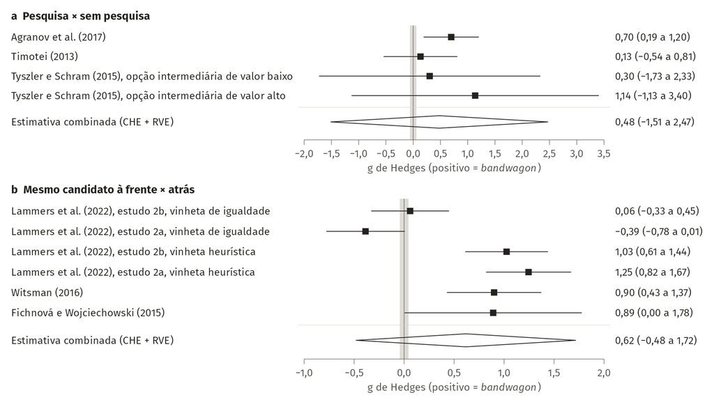

Figura 5: Meta-análises exploratórias, em g de Hedges (positivo = *bandwagon*). O painel **a** compara pesquisa pré-eleitoral com nenhuma pesquisa (3 estudos e 4 efeitos; os dois efeitos de Tyszler e Schram 2015 vêm de valores diferentes da opção intermediária). O painel **b** compara o mesmo candidato mostrado à frente ou atrás (3 estudos e 6 efeitos). Os quadrados são os efeitos, com o intervalo de 95% de cada um. O losango vazado é a estimativa combinada do modelo de efeitos correlacionados e hierárquicos (CHE) com erro-padrão robusto (RVE). Os graus de liberdade de Satterthwaite (1,25 em **a** e 1,46 em **b**) ficam abaixo de 4, e por isso a inferência por RVE não é confiável. A faixa sombreada é ±δ (0,0573 em **a**; 0,044 em **b**). O intervalo de predição fica fora do gráfico (−3,55 a 4,51 em **a**; −7,82 a 9,05 em **b**) e não é interpretado, porque há menos de 5 estudos. O mesmo vale para τ² (0,04 e 0,41). Em cada painel, os efeitos estão ordenados por precisão, do menor ao maior erro-padrão. Todos os efeitos do painel **a** estão em algumas preocupações de risco de viés, e todos os do painel **b**, em risco alto. Note que os painéis têm escalas diferentes.

Em Boukouras et al. (2020), com algumas preocupações de risco de viés, o grupo de comparação viu outras pesquisas da mesma eleição, e o desfecho é a taxa de vitória. A evidência é muito incerta sobre se revelar um conjunto de pesquisas diferente, da mesma eleição, aumenta a vitória do candidato à frente (1 estudo de laboratório, 3 de 3 efeitos na direção *bandwagon*; certeza muito baixa).

Na classe não randomizada, Feltovich e Giovannoni (2022), em risco grave, foi na direção *bandwagon* (efeitos marginais de 0,25 e 0,44), mas a parcela do incumbente na prévia se confunde com o sinal de desempenho que todos recebem. A evidência é muito incerta sobre se ver uma prévia com maior parcela do incumbente aumenta o voto nele (1 estudo de laboratório, com contraste não sorteado; certeza muito baixa).

Nos dois experimentos naturais de proibição de boca de urna, ambos em risco alto no EPOC, os efeitos foram reorientados para o da exposição: Morton et al. (2015), nos territórios franceses de ultramar, foi na direção *bandwagon*, e Chatterjee e Kamal (2019), na Índia, na *underdog* (g −0,29 e −0,42). A proporção, portanto, ficou em 0,50 (IC 95% 0,01 a 0,99; p = 1). A evidência é muito incerta sobre se a divulgação de boca de urna antes do fechamento das urnas aumenta ou reduz o apoio ao líder (2 estudos em direções opostas; certeza muito baixa).

Em Araujo e Gatto (2021a), no Brasil, as urnas que seguiram recebendo votos depois da divulgação oficial da apuração parcial deram mais votos ao candidato à frente nos dois turnos presidenciais de 2018 (+5,69 e +11,76 pontos percentuais). O desfecho é a parcela do candidato em toda a urna, e não só nos votos dados depois dela. O estudo, em risco grave, entrou pela Emenda 1, que decidimos depois de conhecê-lo. A evidência é muito incerta sobre se a divulgação oficial de apuração parcial enquanto a votação continua aumenta o voto no candidato à frente (1 estudo brasileiro na direção *bandwagon*; certeza muito baixa).

## 3.5 Viabilidade e voto estratégico

Frente a nenhuma pesquisa, um experimento de *survey* no México (Cornejo 2023), com 545 respondentes e algumas preocupações de risco de viés, foi na direção de viabilidade (g = 0,19, EP 0,105). Trata-se do único estudo latino-americano sobre pesquisa pré-eleitoral na análise principal. A evidência é muito incerta sobre se ver pesquisa que mostra um candidato de oposição como segundo colocado viável aumenta o apoio a ele (1 estudo no México; certeza muito baixa).

Frente a outro resultado de pesquisa, há dois experimentos. Schlegel, Stoetzer e Kraft (2023) (vinheta hipotética, Reino Unido) foi na direção da deserção (+11 e +17 pontos percentuais), mas seu contraste principal, mantido na contagem, mistura a precisão da pesquisa com a retirada de carga cognitiva. Já Fredén et al. (2024) (eleição real, Suécia) ficou misto, com 2 de 3 efeitos contrários: uma legenda pequena abaixo da cláusula de 4% ganhou votos (g = −0,41 na convenção da célula), o que os autores leem como voto de seguro. A evidência é muito incerta sobre se pesquisas que mostram quais opções são viáveis levam eleitores a desertar para a opção viável (1 estudo a favor e 1 misto, com 2 de 3 efeitos contrários; certeza muito baixa).

## 3.6 *Momentum*

A célula de *momentum* veio da Emenda 4b, anterior à análise de efeitos, mas os árbitros de IA reclassificaram para ela três dos quatro estudos de *momentum* depois de ver os dados.

Dahlgaard et al. (2016) (*survey* na Dinamarca, 1.700 respondentes, algumas preocupações de risco de viés) deu +3,40 pontos percentuais (g = 0,12, EP 0,080), com IC que cruza zero. A evidência é muito incerta sobre se ver pesquisa que mostra um partido ganhando apoio, frente a não ver pesquisa, aumenta o voto nele (*momentum*; 1 estudo; certeza muito baixa).

Já van der Meer, Hakhverdian e Aaldering (2015), num *survey* com 10.643 respondentes nos Países Baixos, comparou o mesmo resultado com e sem enquadramento de crescimento (g = 0,13, EP 0,072), com IC que cruza zero. A evidência é muito incerta sobre se ver pesquisa que mostra um partido ganhando apoio aumenta o voto nele (*momentum*; 1 estudo; certeza muito baixa).

Stolwijk, Schuck e de Vreese (2016), painel na Alemanha em risco grave, favoreceu o partido com cobertura positiva, e Unkelbach, John e Vogel (2022) ficou fora por risco crítico. A evidência é muito incerta sobre se a cobertura de pesquisas favorável a um partido aumenta o voto nele (*momentum*; 1 estudo observacional; certeza muito baixa).

## 3.7 Comparecimento

Três randomizados comparam ver pesquisa com não ver, contraste que não tem sinal previsto (Seção 1.2): Agranov et al. (2017) e Großer e Schram (2010), de laboratório, e Erlich (2023), com candidatos reais e em risco alto. A proporção ficou em 0,67 (IC 95% 0,09 a 0,99; p = 1). A evidência é muito incerta sobre se ver pesquisa, frente a não ver, aumenta ou reduz o comparecimento (2 estudos de laboratório na direção de mobilização e 1 com candidatos reais na de desmobilização; certeza muito baixa).

No experimento de campo de Gerber et al. (2020), em eleições para governador nos Estados Unidos, 126.126 eleitores receberam por carta uma pesquisa de disputa apertada ou folgada, e o estimando é, portanto, o efeito de receber a carta, sem saber quem a leu. As duas estimativas contadas – isto é, o efeito da carta (0,29 ponto percentual) e o de variável instrumental (0,08 ponto por ponto percentual de crença) – tiveram IC 95% inteiro dentro de ±δ (0,046), e tirar a segunda, em outra escala, seria leitura possível, não adotada, que não mudaria o nulo. Note, no entanto, que a célula não foi rebaixada pela indireção do estimando nem pelo relato seletivo, que a faria cair um nível. Receber pesquisa que mostra disputa apertada, em vez de folgada, provavelmente não muda o comparecimento além de 2 p.p. para mais ou para menos (efeito nulo ou trivial; 1 experimento de campo; certeza moderada).

Num jogo *online* com preferências induzidas e 5.845 decisões de mais de mil participantes (Westwood, Messing e Lelkes 2020), afastar de 50:50 a probabilidade de vitória exibida teve g = −0,10 (EP 0,023, com IC 95% inteiro abaixo de −δ), na direção que a complacência e a pivotalidade preveem. A extração não registra se o EP corrige o agrupamento das decisões por participante, e disso depende o rebaixamento por imprecisão. Ver projeções de agregador que mostram probabilidade de vitória mais distante de 50:50 pode reduzir a decisão de votar (direção de desmobilização; 1 estudo; certeza baixa).

Klor e Winter (2017), em risco moderado, está na classe não randomizada pela Emenda 5 e foi na direção de mobilização. A evidência é muito incerta sobre se revelar a distribuição de preferências do eleitorado aumenta o comparecimento (1 estudo de laboratório, antes e depois no mesmo sujeito; certeza muito baixa).

Grillo e Raiber (2024), na França, em risco alto no EPOC, compara momentos de divulgação de boca de urna – afinal, o turno de comparação também teve boca de urna da mídia estrangeira, divulgada mais tarde –, e o comparador foi codificado como outro resultado. A evidência é muito incerta sobre se a boca de urna divulgada mais cedo durante a votação reduz o comparecimento (1 estudo na direção de desmobilização, com IC que cruza zero; certeza muito baixa).

Nos dois experimentos naturais de proibição de boca de urna, Morton et al. (2015) foi na direção de desmobilização (−11 pontos percentuais), e Chatterjee e Kamal (2019) ficou misto. A proporção ficou em 0,00 (IC 95% 0,00 a 0,98; p = 1). A evidência é muito incerta sobre se a divulgação de boca de urna antes do fechamento das urnas reduz o comparecimento (1 estudo na direção de desmobilização e 1 misto; certeza muito baixa).

Foram na direção de mobilização (proporção 1,00; IC 95% 0,16 a 1,00; p = 0,5) o painel de jovens eleitores de Stolwijk e Schuck (2019), nos Países Baixos, com exposição e comparecimento autorrelatados e risco grave, e a descontinuidade no horário de divulgação de Brugarolas e Miller (2021), na Espanha, em risco moderado. Stolwijk e Schuck (2019), no entanto, estima uma associação, e o interesse político move tanto a atenção às pesquisas quanto o comparecimento. O julgamento por IA, não validado, rebaixou a célula um nível por risco de viés, e não dois, como nas outras células não randomizadas com risco grave. Ter visto a divulgação de pesquisas pode aumentar a intenção de votar ou o comparecimento (2 estudos observacionais em eleições reais, ambos na direção de mobilização; certeza baixa).

## 3.8 Sensibilidades e viés de relato

Num agrupamento amplo decidido depois de ver os dados, que junta formatos e comparadores, 9 de 9 experimentos de apoio foram na direção *bandwagon* (proporção 1,00; IC 95% 0,66 a 1,00; p = 0,004). Esse p, como os demais desta seção, vem de teste de sinal *post hoc*, não informa a magnitude e não define rótulo. O julgamento de IA rebaixou esse agrupamento a certeza muito baixa, e a lista de efeitos fora da contagem, decidida depois de ver os dados, tirou dele o único randomizado contrário (Gandhi e Ong 2019).

Só com contexto real, o apoio randomizado se reduz a Farjam (2020), e o não randomizado, a 2 estudos *bandwagon* e 1 *underdog*, todos sobre informação do dia da votação. O padrão na direção *bandwagon* repousa, portanto, sobretudo em laboratório e vinheta.

Com os estudos em risco crítico, Kaplan (2019) ocupa a célula vazia, na direção de desmobilização, e Unkelbach, John e Vogel (2022) leva o *momentum* não randomizado a 2 de 2 (p = 0,5). O ICC de 0,20 não mudou nenhuma contagem. No apoio randomizado, somar os efeitos fora da contagem leva a 10 de 11 (Gandhi e Ong 2019 contra; p = 0,012), e tirar os dados anteriores a 2010, a 8 de 8 (p = 0,008), porque Tyszler e Schram (2015) sai pelo ano da coleta, regra codificada de modo inconsistente nos experimentos de laboratório. No apoio não randomizado, tirar Araujo e Gatto (2021a) deixa 2 de 3. Nenhuma dessas análises tem GRADE próprio (Apêndice F).

Por viés de publicação, o GRADE rebaixou as duas células randomizadas de apoio e o agrupamento amplo randomizado, que só têm estudos positivos, de n entre 12 e 1.113. Nas demais células, a suspeita fica em aberto, pela limitação das fontes.

Dez leituras alternativas, não adotadas, mudariam a composição de células, sobretudo o alvo de Witsman (2016) e a leitura de coordenação em Agranov et al. (2017), Tyszler e Schram (2015) e Tal, Meir e Gal (2015). Nenhuma levaria uma célula a 6 estudos numa só direção, o mínimo para p < 0,05.

## 3.9 Mecanismos

Como nenhuma célula permitiu síntese formal de mecanismos, o que segue, tirado do fichamento por IA, é descritivo (Tabela 3). Dos 41 estudos, 34 marcam algum mecanismo como testado, só 3 por mediação. Na recodificação cega de 10 estudos, os codificadores de IA concordaram em 60% dos casos sobre o mecanismo e em 40% sobre o tipo de evidência. Da codificação de mecanismos, conferimos em bloco só as divergências dessa recodificação, mantido o valor original.

Só Gerber et al. (2020) testa por mediação se a crença na proximidade da disputa transmite o efeito. A pesquisa apertada move a crença, mas a crença quase não move o comparecimento (0,08 ponto por ponto percentual). Trata-se do padrão da teoria rival do efeito só sobre a expectativa.

Lammers et al. (2022), o único estudo que manipula o modo de processamento, acha *bandwagon* sob raciocínio heurístico e *underdog* ou efeito perto de zero sob o motivo moral de igualdade (E5).

O voto estratégico é o canal mais estudado (25 estudos) e o de testes mais diretos. Em laboratório com incentivos, a informação sobre a distribuição de preferências aparece associada a mais deserção para a opção viável (Tal, Meir e Gal 2015; Tyszler e Schram 2013, 2015). Já Araujo e Gatto (2021a) descartou esse canal no Brasil porque o efeito aparece maior no segundo turno, com dois candidatos, padrão também compatível com mudanças na composição de quem vota tarde.

Tabela 3: Hipóteses e elos da teoria da exposição registrada no protocolo e o que a evidência incluída diz sobre cada um. E1 a E8: elos do modelo lógico; R1 a R3: teorias rivais. Síntese descritiva a partir do fichamento por IA; da codificação de mecanismos, conferimos em bloco só as divergências da recodificação cega de 10 estudos (Emenda 7). A certeza GRADE só aparece quando a hipótese coincide com uma célula da síntese principal e qualifica a direção do efeito nessa célula, não o mecanismo; nas demais linhas, sem GRADE. Nenhuma célula tem 4 estudos por nível de moderador, e por isso nenhuma hipótese de moderação teve teste formal.

| Hipótese do protocolo | Estudos que testam com dados | O que a evidência diz | Certeza |
| --- | --- | --- | --- |
| **E1** Exposição → percepção de viabilidade: o eleitor atualiza a expectativa de quem vence (elo intermediário) | (Gerber et al. 2020, mediação; Boukouras et al. 2020; Bursztyn et al. 2023; Erlich 2023; Lago, Guinjoan e Bermúdez 2015; Meffert e Gschwend 2011; Westwood, Messing e Lelkes 2020); só interpretação: (F… | A pesquisa move expectativas. O único teste formal, uma mediação em experimento de campo (Gerber et al. 2020), trata da crença sobre a proximidade da disputa e não encontra efeito dela no comparecimen… | ⊕⊕⊕◯ moderada, só para o efeito nulo de Gerber et al. (2020) no comparecimento (o elo em si fica sem GRADE) |
| **E2** Viabilidade → cálculo estratégico → apoio: abandonar o candidato inviável e migrar para um viável (esperado: *bandwagon* ou migração para o segundo colocado competitivo) | (Agranov et al. 2017; Cornejo 2023; Tal, Meir e Gal 2015; Tyszler e Schram 2013, 2015; Fredén et al. 2024, relato; Alabrese e Fetzer 2024; Gandhi e Ong 2019; Lago, Guinjoan e Bermúdez 2015; Schlegel, … | É o canal com mais estudos e os testes mais diretos (laboratório com incentivos). Dois desses testes (Tal, Meir e Gal 2015; Tyszler e Schram 2015), no entanto, estão nas células de apoio principal, co… | ⊕◯◯◯ muito baixa, nas duas células de viabilidade, sem os testes de laboratório |
| **E3** Exposição → heurística de consenso → apoio: “se muitos apoiam, deve ser bom” (esperado: *bandwagon*) | (Lammers et al. 2022, manipulação; Boukouras et al. 2020; Fichnová e Wojciechowski 2015; Tal, Meir e Gal 2015; van der Meer, Hakhverdian e Aaldering 2015); só interpretação: (Unkelbach, John e Vogel 2… | Direção *bandwagon* sob processamento heurístico, e a ênfase em quem ganha pesa mais que o número. Um único estudo manipula o canal, em vinheta hipotética (Lammers et al. 2022); os demais o inferem a … | ⊕◯◯◯ muito baixa, para o efeito nas células em que esses estudos estão (o canal em si fica sem GRADE) |
| **E4** Exposição → conformidade ou desejo de vencer → apoio: aderir ao lado vencedor (esperado: *bandwagon*) | (Agranov et al. 2017; Stolwijk e Schuck 2019, mediação; Yang et al. 2023, relato); só interpretação: (Dahlgaard et al. 2016; Gasperoni e Mantovani 2015; Kaplan 2019; Morton et al. 2015; Timotei 2013; … | O padrão é compatível em Agranov et al. (2017), em que a maioria vota mais quando há pesquisa. Em Stolwijk e Schuck (2019), a mediação aponta o interesse pela campanha, e não a conformidade. Nenhum es… | sem GRADE (descritivo) |
| **E5** Exposição → simpatia pelo azarão ou equidade → apoio a quem está atrás (esperado: *underdog*) | (Lammers et al. 2022, manipulação; Yang et al. 2023, relato); só interpretação: (Dahlgaard et al. 2016) | Direção *underdog* ou nula sob o motivo moral de igualdade. A evidência vem de uma única manipulação, em vinheta, e as duas replicações dela têm sinais diferentes (Lammers et al. 2022). | sem GRADE (descritivo) |
| **E6** Exposição → emoções (ansiedade, entusiasmo) → apoio (direção esperada ambígua) | (Stolwijk, Schuck e de Vreese 2016, mediação; Yang et al. 2023, relato) | Efeitos indiretos positivos, maiores pelo entusiasmo que pela ansiedade, numa mediação observacional em painel (Stolwijk, Schuck e de Vreese 2016). | sem GRADE (descritivo) |
| **E7** Exposição → complacência → desmobilização (efeito indesejado): apoiadores deixam de votar | (Agranov et al. 2017; Alabrese e Fetzer 2024; Bursztyn et al. 2023; Gerber et al. 2020; Klor e Winter 2017; Westwood, Messing e Lelkes 2020); só interpretação: (Brugarolas e Miller 2021; Grillo e Raib… | No desenho mais forte, um experimento de campo (Gerber et al. 2020), a pesquisa apertada, frente à folgada, provavelmente não muda o comparecimento além de ±2 p.p. Trata-se também do único estudo que … | de ⊕◯◯◯ muito baixa a ⊕⊕⊕◯ moderada, conforme a célula de comparecimento |
| **E8** Divulgação estratégica de pesquisas enviesadas → exposição: quem tem interesse publica números favoráveis para induzir *bandwagon* (afeta o conteúdo da exposição, não o sinal do efeito) | (Boukouras et al. 2020); só interpretação: (Alabrese e Fetzer 2024; Farjam 2020; Lammers et al. 2022; Morton et al. 2015; Timotei 2013; Tyszler e Schram 2015) | Só um estudo testa a divulgação seletiva. Nele, revelar apenas as pesquisas mais favoráveis a um candidato aumentou a vitória dele nos três experimentos de laboratório, inclusive quando o eleitor foi … | ⊕◯◯◯ muito baixa, para o efeito na célula de Boukouras et al. (2020) |
| **R1** Teoria rival 1, efeitos que se anulam: *bandwagon* e *underdog* coexistem, e um efeito na média perto de zero esconde efeitos individuais opostos | (Cornejo 2023; Lammers et al. 2022) | Seis estudos têm linhas de subgrupo com sinais opostos no apoio, mas só dois entre grupos de eleitores ou de processamento (Cornejo 2023; Lammers et al. 2022). Como o protocolo exige pelo menos três, … | sem GRADE (descritivo); sem teste formal (menos de 3 estudos com subgrupos de sinais opostos, como exige o protocolo) |
| **R2** Teoria rival 2, efeito só de expectativa: a pesquisa muda expectativas, mas não o voto | (Gerber et al. 2020, mediação) | É o padrão de Gerber et al. (2020), em que a pesquisa de disputa apertada move a crença sobre a proximidade, mas provavelmente não o comparecimento além de ±2 p.p. O achado vale só para o comparecimen… | ⊕⊕⊕◯ moderada, só para o comparecimento (para o apoio, sem GRADE) |
| **R3** Teoria rival 3, efeito artefatual do experimento: com candidatos hipotéticos, o efeito reflete a demanda do experimentador (esperado: maior em contextos hipotéticos e induzidos) | nenhum | No alvo principal de apoio, os 8 experimentos hipotéticos ou induzidos e o de laboratório não randomizado vão na direção *bandwagon*. Nenhum estudo, no entanto, mede pesquisa pré-eleitoral numa eleiçã… | sem GRADE (descritivo); sem teste formal (menos de 4 estudos por nível) |

## 3.10 Moderadores

Os moderadores também são descritivos, porque nenhuma célula chegou ao mínimo do protocolo, de 3 estudos por nível para estimar por subgrupo e 4 para testar. A direção prevista pelos elos E2 a E4 aparece em todos os experimentos do alvo principal, e a *underdog*, prevista pelo E5, só na condição moral de Lammers et al. (2022) e numa proibição de boca de urna (Chatterjee e Kamal 2019).

Quanto ao realismo, o *bandwagon* dos experimentos de apoio vem sobretudo de vinhetas e laboratórios, enquanto os não randomizados em eleição real tratam do dia da votação. No comparecimento, os 5 não randomizados em eleição real ficaram com 2 de mobilização, 2 de desmobilização e 1 misto (Figura 6; comparação descritiva, *post hoc* e sem teste). Ali, o realismo se confunde com o formato, porque os de desmobilização são de boca de urna.

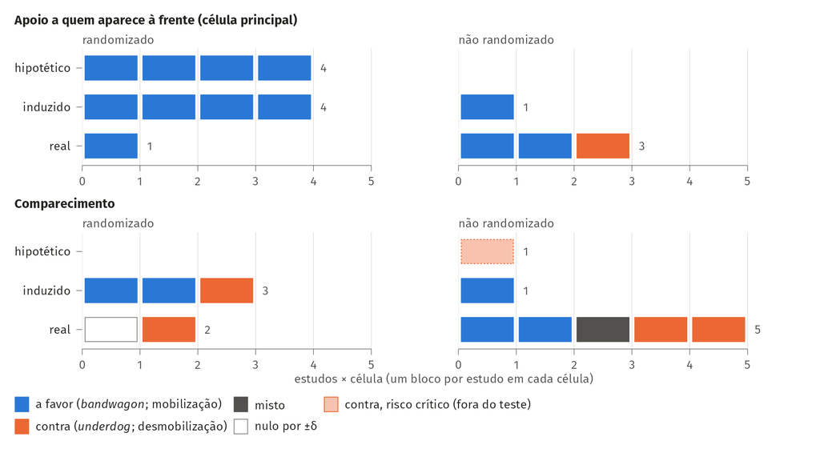

Figura 6: Direção do efeito por realismo do contexto (eleição hipotética, preferências induzidas em laboratório ou eleição real), separada por classe de desenho, no apoio a quem aparece à frente (célula principal) e no comparecimento. Cada bloco é um estudo numa célula da síntese principal. O bloco claro e tracejado é um estudo em risco crítico, fora do teste de sinal. No apoio, o único experimento em contexto real (Farjam 2020) é uma votação experimental com organizações reais, sem eleição em curso, e os estudos reais não randomizados tratam de informação do dia da votação. A comparação é descritiva, sem teste.

A direção não variou com o número de competidores: foram *bandwagon* os 4 randomizados com dois, em que não há deserção estratégica, e os 5 com três ou mais. Nos estudos que variam a proximidade, a disputa apertada aparece com mais comparecimento (Alabrese e Fetzer 2024; Bursztyn et al. 2023; Klor e Winter 2017), mas dois só têm efeitos fora da contagem, e o padrão não aparece no desenho mais forte (Gerber et al. 2020). As maiores estimativas vêm de exposições do dia da votação (Araujo e Gatto 2021a; Morton et al. 2015), em que o momento também se confunde com o desenho.

Em Cornejo (2023), com heterogeneidade pré-especificada, o efeito de viabilidade foi maior entre partidários (g = 0,33) que entre independentes (0,09). Detectar efeitos que se anulam exigiria pelo menos 3 estudos com subgrupos de sinais opostos, e só 2 os têm (Cornejo 2023; Lammers et al. 2022). Como nenhum dos 11 estudos de comparecimento da síntese tem voto obrigatório codificado como sim, não se pode examinar se ele elimina o canal da desmobilização.

# 4 Discussão

## 4.1 Resumo dos achados

No apoio a quem aparece à frente, os 9 experimentos das três células randomizadas apontaram na direção *bandwagon*, mas a evidência é muito incerta sobre o efeito de ver uma pesquisa no apoio ao líder. Das três células não randomizadas, com 1 ou 2 estudos, duas vão na direção *bandwagon*, e a de boca de urna tem um estudo em cada direção; as seis têm certeza muito baixa. As classes de desenho estimam coisas diferentes, mas apontam para o mesmo lado na maior parte das células, sem teste. Em parte dos experimentos, no entanto, esse padrão é compatível com coordenação estratégica ou com comparecimento diferencial.

No comparecimento, as direções se dividem. No único experimento de campo, pesquisa apertada, em vez de folgada, provavelmente não muda o comparecimento além de 2 pontos percentuais (certeza moderada). Já no jogo *online* de Westwood, Messing e Lelkes (2020), que manipula a mesma proximidade percebida, projeções mais distantes de 50:50 podem reduzir a decisão de votar (certeza baixa), padrão que a teoria rival do artefato prevê, sem testá-la. Ter visto a divulgação de pesquisas pode aumentar a participação (certeza baixa), e a evidência sobre a boca de urna é muito incerta.

Nos experimentos de *survey* com partidos reais, os g ficaram entre 0,12 e 0,19 (Cornejo 2023; Dahlgaard et al. 2016; van der Meer, Hakhverdian e Aaldering 2015), todos com IC que cruza zero. As duas meta-análises exploratórias, com 3 estudos cada e menos de 4 graus de liberdade, têm intervalos que cruzam zero e não informam o tamanho do efeito.

As três contribuições anunciadas ficam de pé em termos modestos, com a ressalva de que risco de viés e certeza não tiveram validação humana: (i) há agora um inventário com protocolo da evidência causal desde 2010; (ii) voto estratégico, em sentido estrito, e *momentum* têm poucos estudos, e o padrão na direção *bandwagon* repousa sobretudo em laboratório e vinheta, numa comparação descritiva e *post hoc*; e (iii) o mapa brasileiro é, sobretudo, de lacunas desta busca.

## 4.2 Relação com revisões anteriores

Barnfield (2020) argumenta que experimentos que apresentam a pesquisa como único estímulo tendem a achar efeito, com pouco a ensinar por falta de realismo, e que pistas de contexto, como a identificação partidária, atenuam o efeito da pesquisa. O padrão desta síntese é compatível com essa advertência, sem confirmá-la. Na amostra de Barnfield, só 10 artigos discutem mobilização, enquanto aqui 17 estudos medem o comparecimento.

Moy e Rinke (2012) concluíram que a literatura não permitia dizer se o *bandwagon* ou o *underdog* era mais comum e que os efeitos dependem do contexto político e midiático. Os achados antigos de *underdog* que eles relatam não se reproduzem aqui, talvez pelos desenhos, em que a pesquisa é o único estímulo ou o voto tem pagamento fixado pelo experimento. Por isso comparamos enquadramentos, não estimativas.

Coşgun (2026) registra que as afirmações causais mais fortes da área vêm de laboratório e de experimentos de *survey*, concentrados nos Estados Unidos e em painéis de conveniência, como os estudos incluídos aqui. Sobre Hardmeier (2008), sem texto aberto, não há como comparar conclusões.

## 4.3 Completude, aplicabilidade e limitações da evidência

Dos 9 experimentos de apoio do agrupamento amplo, 8 usaram laboratório ou vinheta. Nenhum estudo com dados só do Brasil trata de pesquisas pré-eleitorais publicadas, e o país aparece só entre os 46 do corte transversal de Lago, Guinjoan e Bermúdez (2015), fora da contagem. Trata-se também de uma lacuna da busca, que não incluiu a SciELO, âncoras em português ou espanhol, periódicos e anais brasileiros nem consulta a especialistas.

Cada célula tem de 1 a 4 estudos, e, nas de 1 estudo, o IC 95% da proporção vai de 0,03 a 1,00 ou de 0,00 a 0,98. Há efeitos lidos de figura (Tyszler e Schram 2015), medidas de grupo (Agranov et al. 2017; Tyszler e Schram 2015) e n ou valor derivados (Kaplan 2019; Lammers et al. 2022; Meffert e Gschwend 2011). Nenhum resultado randomizado ficou em risco baixo, e o confundimento foi grave ou crítico na maioria dos não randomizados. Contrastes e estimandos são heterogêneos, e 7 estudos só têm efeitos fora da contagem; alguns usam eleições ou coletas anteriores a 2010 (Chatterjee e Kamal 2019; Klor e Winter 2017; Morton et al. 2015; Tyszler e Schram 2015). Por fim, o δ de 2 pontos não é pequeno para eleições decididas por margem estreita, e o nulo por ±δ nada diz sobre efeitos menores.

A evidência nada diz sobre embargos como o que o STF derrubou em 2006, o voto obrigatório como freio da desmobilização, a confiança nas pesquisas como moderador, o efeito de projeções sobre a escolha de voto e referendos. O arcabouço de exposição individual também não capta o efeito das pesquisas sobre doadores, imprensa, alianças e desistência de candidatos, canal que só os estudos agregados de proibição captam em parte.

## 4.4 Limitações do processo e da síntese

Inferimos, sem medir, a direção provável dos vieses. Na busca, as fontes ficaram restritas (A1), as âncoras foram montadas por IA, com *recall* final não independente (A3), e conferimos a pré-revisão PRESS, feita por IA (A4), sem revisão PRESS independente.

A triagem, por sua vez, foi só por IA (A2), sem *recall*, e a validação cega prevista não foi feita. Concordar com a IA depois de ver as decisões não vale como codificação cega. A triagem complementar dos registros sem resumo também foi só por IA, sem estimativa de quantos elegíveis se perderam nas 156 exclusões, e o comando que a registrou grava o ator como humano. Não foram recuperados 338 de 522 relatos, sem contato com autores (A5); se eles forem mais vezes nulos, a direção dominante fica superestimada. A deduplicação dos 145 pares só foi aplicada depois da triagem (Emenda 8).

Na extração, a recodificação cega ficou abaixo do limiar do protocolo, mas a contingência de redefinir e recodificar não foi acionada, e as divergências foram resolvidas pelo valor original. Reextração e arbitragem dos efeitos usaram o mesmo modelo, e 240 das 772 correções foram estendidas sem nova arbitragem. Conferimos os 560 efeitos em bloco, sem registro item a item que o leitor possa verificar. Erros aleatórios de sinal atenuam a direção dominante; já erros sistemáticos do mesmo modelo têm direção imprevisível.

Os julgamentos de risco de viés são só de IA, e o árbitro, do mesmo modelo do avaliador A, seguiu-o em 79 de 88 domínios; não fizemos a confirmação em bloco da Emenda 4d (Emenda 6a). Isso afeta a certeza e a exclusão por risco crítico, mas não o sinal dos efeitos. Na síntese, a estrutura de células, o sinal por alvo, os efeitos fora da contagem e os nulos por ±δ foram decididos depois de ver os dados (Emenda 5). Planejamos e não fizemos as análises de moderadores e subgrupos, de equidade, de evidência faltante por célula e de modelo de seleção.

Um só subagente julgou o GRADE, com notas genéricas e sem validação humana, e um avaliador humano pode rever quatro escolhas dele: (i) não rebaixar os corpos cuja única preocupação de risco de viés é o relato seletivo (Boukouras et al. 2020; Gerber et al. 2020; van der Meer, Hakhverdian e Aaldering 2015; Westwood, Messing e Lelkes 2020), rebaixamento que tiraria um nível das células de Westwood, Messing e Lelkes (2020) e Gerber et al. (2020); (ii) rebaixar só um nível a célula de Stolwijk e Schuck (2019) e Brugarolas e Miller (2021), quando outras células não randomizadas com risco grave desceram dois; (iii) rebaixar por viés de publicação o agrupamento amplo de apoio randomizado, que sem isso teria certeza baixa; e (iv) julgar a imprecisão das células de 1 estudo por regra única, um nível sem medida de precisão e dois com IC que cruza zero. Rever essas escolhas mudaria certezas, mas não a contagem por direção.

No relato, lemos a versão de 24/09/2026, da qual esta deriva sem mudar a análise, e aprovamos o conteúdo desta, já com a Emenda 8, antes da entrega. Como todos os modelos são do mesmo provedor, erros correlacionados não aparecem na concordância. Três defeitos da ferramenta de revisão afetaram registros de triagem, mas não efeitos.

# 5 Da evidência à prática: implicações

## 5.1 O que isso significa para o debate brasileiro

Nos experimentos, as estimativas apontaram a favor de quem aparece à frente, mas a evidência é muito incerta. Num experimento de campo nos Estados Unidos, onde o voto é facultativo, pesquisa apertada, em vez de folgada, provavelmente não muda o comparecimento além de 2 pontos percentuais. Nesta busca, que não incluiu a SciELO, o único estudo com dados só do Brasil (Araujo e Gatto 2021a) trata da divulgação oficial da apuração parcial com a votação em curso, e não de pesquisa eleitoral. A precisão das pesquisas, objeto dos projetos de lei de 2022, não foi examinada.

Sobre a restrição à divulgação, a evidência direta vem de proibições de divulgar pesquisa de boca de urna antes do fechamento das urnas, na França e na Índia, em direções opostas e com certeza muito baixa, e de Lago, Guinjoan e Bermúdez (2015), fora da contagem. Note que essas proibições correspondem à regra brasileira de só divulgar levantamentos do dia a partir das 17h de Brasília, e não ao embargo pré-eleitoral que o STF derrubou em 2006; Araujo e Gatto (2021a), por sua vez, trata de uma brecha, em 2018, da regra de só divulgar resultados depois do fechamento das urnas: o voto de quem ainda estava na fila quando a apuração começou a ser divulgada. Sozinha, a evidência não demonstra que a divulgação de pesquisas muda votos, nem que é inócua, e a consequência prática dessa incerteza depende, portanto, de quem carrega o ônus da prova – isto é, de uma escolha jurídica e normativa.

Examinamos a transferibilidade pelos quatro fatores fixados no protocolo, sem segundo rebaixamento, porque a diferença de contexto já entrou na indireção do GRADE. Nenhum dos 11 estudos de comparecimento da síntese tem voto obrigatório codificado como sim, e nenhum experimento de viabilidade trata do primeiro turno de uma eleição em dois turnos, onde opera o voto útil a que Pereira e Nunes (2024) atribuem parte da distância entre pesquisas e urnas em 2022. Nenhum estudo avalia a regulação brasileira, e só um relata a confiança nas pesquisas como moderador. A comparação regional pedida pelo protocolo não é possível com um estudo brasileiro sobre apuração parcial e Cornejo (2023) na América Latina. Com certeza muito baixa, a única implicação admissível é que, se as regras mudarem, a mudança pode ser desenhada para permitir avaliação. A decisão cabe a quem tem mandato para tomá-la.

## 5.2 Implicações para a pesquisa

As implicações para a pesquisa saem dos domínios que rebaixaram a certeza: faltam (i) estudos com eleições reais no Brasil, como experimentos de *survey* em campanhas ou experimentos naturais com variações na divulgação; (ii) comparadores que correspondam a regras reais, com pesquisa antiga e outras pistas para embargos e com outro resultado de pesquisa para as propostas sobre precisão; (iii) pré-registro e relato completo; (iv) estudos maiores, com o efeito em pontos percentuais e erro-padrão; (v) medidas do apoio a quem lidera, da deserção estratégica e do comparecimento no mesmo desenho; e (vi) estimativas por subgrupo, inclusive do lado que a pesquisa mostra atrás. Uma atualização desta síntese precisaria incluir a SciELO e outras bases, registros de estudos, termos de proibição, embargo, apuração parcial e comparecimento, além de revisão PRESS humana, validação humana do risco de viés e da certeza e codificação cega da triagem.

# 6 Conclusões

A evidência não diz de quanto é o efeito das pesquisas sobre o voto, e tampouco permite afirmar que elas não têm efeito. Nesta busca, que não incluiu a SciELO, o único estudo com dados só do Brasil (Araujo e Gatto 2021a) trata da divulgação oficial da apuração parcial com a votação em curso, e não de pesquisa eleitoral. Sozinha, a evidência não demonstra que a divulgação de pesquisas muda votos, nem que é inócua. Risco de viés e certeza foram julgados só por agentes de IA, e a validação humana dessas etapas pode mudar as certezas.

# Informações adicionais

**Diferenças entre protocolo e síntese.** Houve onze desvios, com data, momento e motivo no Apêndice B: (i) E001, em 19/09/2026, contingência prevista que ampliou a estratégia em inglês; (ii) E002, no mesmo dia, antes da triagem, que trocou a B01 pela B05 e tirou a independência do *recall*; (iii) Emenda 1, em 20/09/2026, depois de ver o estudo, que pôs a apuração parcial no C2 e afeta só Araujo e Gatto (2021a); (iv) Emenda 2, na mesma data, decidida pelo coordenador de IA depois do piloto e endossada por nós, sobre três variáveis do *codebook*; (v) Emenda 3, em 23/09/2026, antes do risco de viés, que copiou os *codebooks* e registrou a troca do árbitro, decisão nossa, por custo; (vi) Emenda 4, na mesma data, depois da extração e antes da análise de efeitos, sobre EPOC, *momentum* e ICC; (vii) Emenda 5, depois da primeira síntese, com o alvo na célula, efeitos fora da contagem, críticos fora, metas exploratórias, nulos por ±δ e sensibilidades; (viii) Emenda 6, depois do G9, com a correção da atribuição humana (6a) e a triagem por IA dos registros sem resumo (6b), sem novo incluído; (ix) outros, como a tabela de resumo única para todas as comparações, a meta do mesmo candidato atrás, rodada depois do GRADE, e análises planejadas e não feitas; (x) Emenda 7, em 30/09/2026, decidida depois do G9 e de ver os dados. Ela registra a nossa conferência em bloco, declara não validados o risco de viés e o GRADE e não feita a validação cega, adota o rótulo de síntese, deixa a marca de produto não validado só na declaração de IA (desvio parcial da seção 10 do protocolo), tira a caixa, transforma o material complementar em apêndices e publica o pacote. Nenhum dado, decisão em vigor ou contagem mudou; e (xi) Emenda 8, na mesma data, decidida depois do G9 e de ver os dados, que corrigiu a ferramenta e aplicou a deduplicação decidida na Emenda 7, com a decisão mais inclusiva nos registros absorvidos já triados e 9 pares de versão ligados por nós, e mudou contagens do fluxo, mas não os incluídos.

**Registro e protocolo.** Decidimos, em 19/09/2026, não registrar esta síntese. Aprovamos o protocolo no portão G2, em 19/09/2026, e a ferramenta o congelou com *hash* no *log* do projeto. Protocolo e emendas estão no pacote de replicação.

**Financiamento.** Esta síntese não recebeu financiamento específico.

**Conflitos de interesse.** Declaramos não ter conflito de interesses nem relação com a Anthropic, provedora dos modelos de IA usados.

**Contribuições (CRediT).** Felipe Lamarca e Lucas Berti contribuíram igualmente. Os dois: conceituação, curadoria de dados, análise formal, investigação, metodologia, administração do projeto, recursos, *software*, supervisão, validação, visualização, escrita (primeira redação) e escrita (revisão e edição). Obtenção de financiamento: não se aplica.

**Disponibilidade de dados, código e materiais.** (i) São públicos, na página do projeto (https://felipelamarca.com/pesquisas-eleitorais-rs/), este artigo com os apêndices, em PDF e HTML, o resumo em linguagem simples e a página interativa. (ii) É público o pacote de replicação (https://felipelamarca.com/pesquisas-eleitorais-rs/pacote-replicacao.zip), com licença MIT para o código e CC BY 4.0 para textos e dados, sem resumos nem e-mails de terceiros. Ele traz protocolo, emendas, pergunta, teoria do programa e *codebooks*, estratégias de busca ativas, registro das buscas e conferência do PRESS, registros só com metadados bibliográficos, decisões de deduplicação, triagem e texto completo, contagens do PRISMA, fichamento, efeitos extraídos, risco de viés, entradas, saídas e *scripts* da síntese, a declaração de IA gerada do *log*, a tabela de agentes, as nossas declarações, as pendências abertas, listas de conferência, uma cópia da ferramenta de revisão, que roda a síntese, e um manifesto com o *hash* de cada arquivo. (iii) Com ele, refaz-se a síntese a partir dos efeitos extraídos (conversões, células, testes de sinal, metas, figuras e tabelas), com R 4.5.2, metafor 5.0.1, clubSandwich 0.7.0, Quarto 1.9.35 e Typst 0.14.2. Extração, elegibilidade e risco de viés dependem dos textos completos, que não são redistribuídos, e o pacote traz os identificadores para obtê-los. (iv) É público o repositório GitHub do projeto (https://github.com/felipelmc/pesquisas-eleitorais-rs), com os *prompts* dos agentes, as fichas com trechos, os pacotes de revisão humana sem resumos e o *log* completo. Ficam só conosco os textos completos, que não são redistribuídos, e, com acesso sob pedido, os resumos de terceiros (exportações das buscas, registros e lotes de triagem), os pareceres dos triadores de IA e o registro de decisões da triagem, que citam trechos dos resumos; a pasta `publico/` do repositório traz versões deles sem resumos e sem trechos. (v) Não há identificador persistente.

**Declaração de uso de inteligência artificial.**

**RASCUNHO NÃO VALIDADO.** Ficaram sem validação humana: (i) o risco de viés e a certeza da evidência, julgados só por agentes de IA (P033, P035, P036 e P042); e (ii) a validação cega da triagem, que não foi feita (P006, P007 e P008). Usamos modelos da Anthropic, pelo Claude Code, entre 19/09/2026 e 30/09/2026. O coordenador foi `claude-opus-5-5`, e os subagentes, `claude-sonnet-5`, `claude-opus-5` e `claude-opus-5-5`, com o modelo de cada etapa nos Métodos (seções 2.4 a 2.8) e no Apêndice G. O *log* não registra o modelo do coordenador. A IA decidiu a triagem e a triagem complementar, propôs a elegibilidade, a extração e as correções dos efeitos, julgou o risco de viés e a certeza e corrigiu a ferramenta da revisão para aplicar a deduplicação. Modelos de IA também participaram da redação deste texto e do resumo em linguagem simples; revisamos o texto e respondemos por ele. Usar IA foi escolha nossa, para a variante rápida, com a conferência humana feita por nós dois, em bloco, sem dupla independente. Na triagem, a concordância entre os agentes foi de 0,97 (κ 0,90; PABAK 0,94), sem IC, e o *recall* não foi calculado. A recodificação cega da extração concordou em 58,5%, abaixo do limiar do protocolo, e, no risco de viés, o árbitro seguiu o avaliador A em 79 de 88 domínios. A concordância entre agentes mede consistência, e não acurácia. Conferimos em bloco partes da busca, da seleção e da extração (Seção 2.9), e o risco de viés e a certeza da evidência foram julgados só por IA, sem validação humana. Não há conflito de interesses, e o custo do acesso e os termos de retenção dos dados não foram registrados. As limitações são um só provedor, um árbitro do mesmo modelo do avaliador A e versões de modelo que mudam. A responsabilidade pelo conteúdo é nossa, inclusive pela decisão de usar IA. A declaração completa, gerada do *log*, está no pacote de replicação, e o quadro por etapa, no Apêndice G.

**Versão e citação.** Versão de entrega de 30/09/2026. Reescreve a de 24/09/2026 como artigo único com apêndices, sem mudar células, certezas nem metas; a deduplicação aplicada mudou só contagens do fluxo. Como citar: Lamarca, Felipe, e Lucas Berti. 2026. *Pesquisas eleitorais publicadas mudam o voto? Síntese sistemática de evidências, conduzida com agentes de IA, sobre os efeitos* bandwagon *e* underdog *e o comparecimento*. Documento de trabalho, versão de 30/09/2026. https://felipelamarca.com/pesquisas-eleitorais-rs/.

# Referências

Agranov, Marina, Jacob K. Goeree, Julian Romero e Leeat Yariv. 2012. *What Makes Voters Turn Out: The Effects of Polls and Beliefs*. SSRN Electronic Journal. doi:10.2139/ssrn.2029598.

Agranov, Marina, Jacob K. Goeree, Julian Romero e Leeat Yariv. 2017. “What Makes Voters Turn Out: The Effects of Polls and Beliefs”. *Journal of the European Economic Association* 16(3): 825–56. doi:10.1093/jeea/jvx023.

Alabrese, Eleonora. 2022. *National Polls, Local Preferences and Voters’ Behaviour: Evidence from the UK General Elections*. SSRN Electronic Journal. doi:10.2139/ssrn.4265932.

Alabrese, Eleonora e Thiemo Fetzer. 2024. *Opinion Polls, Turnout and the Demand for Safe Seats*. SSRN Electronic Journal. doi:10.2139/ssrn.4803850.

Araujo, Víctor e Malu A. C. Gatto. 2021a. “Casting Ballots When Knowing Results”. *British Journal of Political Science* 52(4): 1709–27. doi:10.1017/s000712342100034x.

Araujo, Víctor e Malu A. C. Gatto. 2021b. *Casting Ballots When Knowing Results*. doi:10.33774/apsa-2021-5d090-v2.

Barnfield, Matthew. 2020. “Think Twice Before Jumping on the Bandwagon: Clarifying Concepts in Research on the Bandwagon Effect”. *Political Studies Review* 18(4): 553–74. doi:10.1177/1478929919870691.

Bischoff, Ivo e Henrik Egbert. 2013. “Social Information and Bandwagon Behavior in Voting: An Economic Experiment”. *Journal of Economic Psychology* 34: 270–84. doi:10.1016/j.joep.2012.10.009.

Boon, Michele Hilton e Hilary Thomson. 2021. “The Effect Direction Plot Revisited: Application of the 2019 Cochrane Handbook Guidance on Alternative Synthesis Methods”. *Research Synthesis Methods* 12(1): 29–33. doi:10.1002/jrsm.1458.

Boukouras, Aristotelis, Will Jennings, Lunzheng Li e Zacharias Maniadis. 2020. *Can Biased Polls Distort Electoral Results? Evidence From The Lab*. SSRN Electronic Journal. doi:10.2139/ssrn.3644952.

Brasil. 1997. *Lei nº 9.504, de 30 de setembro de 1997: estabelece normas para as eleições*. Diário Oficial da União. https://www.planalto.gov.br/ccivil_03/leis/l9504.htm (24 de setembro de 2026).

Brugarolas, Pablo e Luis Miller. 2021. “The Causal Effect of Polls on Turnout Intention: A Local Randomization Regression Discontinuity Approach”. *Political Analysis* 29(4): 554–60. doi:10.1017/pan.2020.50.

Bursztyn, Leonardo, Davide Cantoni, Patricia Funk, Felix Schönenberger e Noam Yuchtman. 2017. *Identifying the Effect of Election Closeness on Voter Turnout: Evidence from Swiss Referenda*. National Bureau of Economic Research. doi:10.3386/w23490.

Bursztyn, Leonardo, Davide Cantoni, Patricia Funk, Felix Schönenberger e Noam Yuchtman. 2023. “Identifying the Effect of Election Closeness on Voter Turnout: Evidence from Swiss Referenda”. *Journal of the European Economic Association* 22(2): 876–914. doi:10.1093/jeea/jvad038.

Bursztyn, Leonardo, Davide Cantoni, Patricia Funk e Noam Yuchtman. 2017. *Polls, the Press, and Political Participation: The Effects of Anticipated Election Closeness on Voter Turnout*. RePEc: Research Papers in Economics.

Câmara dos Deputados. 2022. *Projeto de Lei nº 2.567, de 2022: altera a Lei nº 9.504, de 30 de setembro de 1997, para tipificar a conduta de publicar pesquisa eleitoral com dados que divergem, além da margem de erro, dos resultados apurados nas urnas e dá outras providências*. Projeto de Lei, autoria do Deputado Ricardo Barros (PP-PR), apresentado em 06/10/2022. https://www.camara.leg.br/proposicoesWeb/fichadetramitacao?idProposicao=2335321 (24 de setembro de 2026).

Campbell, Mhairi, Joanne E. McKenzie, Amanda Sowden, Srinivasa Vittal Katikireddi, Sue E. Brennan, Simon Ellis, Jamie Hartmann-Boyce, et al. 2020. “Synthesis Without Meta-Analysis (SWiM) in Systematic Reviews: Reporting Guideline”. *BMJ* 368: l6890. doi:10.1136/bmj.l6890.

Chatterjee, Somdeep e Jai Kamal. 2019. *Voting for the Underdog or Jumping on the Bandwagon? Evidence from India’s Exit Poll Ban*. SSRN Electronic Journal. doi:10.2139/ssrn.3332196.

Clopper, C. J. e E. S. Pearson. 1934. “The Use of Confidence or Fiducial Limits Illustrated in the Case of the Binomial”. *Biometrika* 26(4): 404–13. doi:10.1093/biomet/26.4.404.

Cochrane Effective Practice and Organisation of Care (EPOC). 2017. *Suggested Risk of Bias Criteria for EPOC Reviews*. EPOC Resources for review authors. https://epoc.cochrane.org/sites/epoc.cochrane.org/files/uploads/Resources-for-authors2017/suggested_risk_of_bias_criteria_for_epoc_reviews.pdf (24 de setembro de 2026).

Corbetta, Piergiorgio e Pasquale Colloca. 2013. “Uso delle euristiche nella scelta elettorale: un approccio basato sulla simulazione della decisione di voto”. *Quaderni dell’Osservatorio elettorale QOE - IJES* 70(2): 7–30. doi:10.36253/qoe-9561.

Cornejo, Rodrigo Castro. 2023. “Do (Perceptions of) Electoral Polling Affect Voters’ Behavior? Campaigns, Partisan Bias, and Strategic Voting”. *Revista Latinoamericana de Opinión Pública* 11(2): 73–108. doi:10.14201/rlop.29606.

Coşgun, Melih. 2026. “Electoral Campaigns and Voter Behavior: A Systematic Literature Review and Agenda for Future Research”. *Akademik Yaklaşımlar Dergisi / Journal of Academic Approaches* 17(2): 1–20. doi:10.54688/ayd.1760361.

Dahlgaard, Jens Olav, Jonas Hedegaard Hansen, Kasper Møller Hansen e Martin Vinæs Larsen. 2015a. “How Do Opinion Polls Affect Voters? The Effect of Opinion Polls on the Danes’ Voting Behavior and Sympathy for Parties”. *Politica* 47(1). doi:10.7146/politica.v47i1.131475.

Dahlgaard, Jens Olav, Jonas Hedegaard Hansen, Kasper Møller Hansen e Martin Vinæs Larsen. 2015b. “Hvordan påvirkes vælgerne af meningsmålinger? Effekten af meningsmålinger på danskernes stemmeadfærd og sympati for partierne”. *Politica* 47(1). doi:10.7146/politica.v47i1.131474.

Dahlgaard, Jens Olav, Jonas Hedegaard Hansen, Kasper Møller Hansen e Martin Vinæs Larsen. 2016. “How Are Voters Influenced by Opinion Polls? The Effect of Polls on Voting Behavior and Party Sympathy”. *World Political Science* 12(2): 283–300. doi:10.1515/wps-2016-0012.

Dahlgaard, Jens Olav, Jonas Hedegaard Hansen, Kasper Møller Hansen e Martin Vinæs Larsen. 2017. “How Election Polls Shape Voting Behaviour”. *Scandinavian Political Studies* 40(3): 330–43. doi:10.1111/1467-9477.12094.

Erlich, Aaron. 2023. *Measuring How Information Changes Electoral Uncertainty in a Developing Democracy: Experimental Evidence from the Country of Georgia*. doi:10.31219/osf.io/mwg7u.

Fairstein, Roy, Adam Lauz, Kobi Gal e Reshef Meir. 2018. *Predicting Strategic Voting Behavior with Poll Information*. arXiv (Cornell University). doi:10.48550/arxiv.1805.07606.

Fairstein, Roy, Adam Lauz, Reshef Meir e Kobi Gal. 2019. “Modeling People’s Voting Behavior with Poll Information”. Em *International Joint Conference on Autonomous Agents and Multiagent Systems*, 1422–30. doi:10.65109/srvt6467.

Farjam, Mike. 2020. “The Bandwagon Effect in an Online Voting Experiment With Real Political Organizations”. *International Journal of Public Opinion Research* 33(2): 412–21. doi:10.1093/ijpor/edaa008.

Feltovich, Nick e Francesco Giovannoni. 2022. “Campaign Messages, Polling, and Elections: Theory and Experimental Evidence”. *American Journal of Political Science* 68(2): 408–26. doi:10.1111/ajps.12722.

Fichnová, Katarína e P. Wojciechowski. 2015. “Election Opinion Polls and Their Impacts on Voting Preferences of Slovak and Polish Voters”.

Fredén, Annika. 2016. “Strategic Voting Under Coalition Governments”. PhD thesis. Lund University Publications (Lund University). doi:10.13140/rg.2.1.3580.3125.

Fredén, Annika. 2021. “How Polling Trends Influence Compensational Coalition-Voting”. *Frontiers in Political Science* 3: 598771. doi:10.3389/fpos.2021.598771.

Fredén, Annika, Bastiaan Bruinsma, Nora Theorin e Henrik Oscarsson. 2024. “Insurance Voting in the Centre: An Experimental Approach”. *International Journal of Public Opinion Research* 36(3): edae041. doi:10.1093/ijpor/edae041.

Gandhi, Jennifer e Elvin Ong. 2019. “Committed or Conditional Democrats? Opposition Dynamics in Electoral Autocracies”. *American Journal of Political Science* 63(4): 948–63. doi:10.1111/ajps.12441.

Garritty, Chantelle, Candyce Hamel, Marialena Trivella, Gerald Gartlehner, Barbara Nussbaumer-Streit, Declan Devane, Chris Kamel, Ursula Griebler e Valerie J. King. 2024. “Updated Recommendations for the Cochrane Rapid Review Methods Guidance for Rapid Reviews of Effectiveness”. *BMJ* 384: e076335. doi:10.1136/bmj-2023-076335.

Gasperoni, Giancarlo e Debora Mantovani. 2015. “The Impact of Exposure to Pre-Election Polls on Voting Behaviour”. *Italian Political Science Review/Rivista Italiana di Scienza Politica* 45(1): 1–23. doi:10.1017/ipo.2015.3.

Geers, Sabine, L. Bos e Claes H. de Vreese. 2018. “Effects of Issue and Poll News on Electoral Volatility: Conversion or Crystallization?” *Acta Politica* 54(4): 521–39. doi:10.1057/s41269-018-0089-x.

Gerber, Alan S., Mitchell Hoffman, John Morgan e Collin Raymond. 2017a. *One in a Million: Field Experiments on Perceived Closeness of the Election and Voter Turnout*. National Bureau of Economic Research. doi:10.3386/w23071.

Gerber, Alan S., Mitchell Hoffman, John Morgan e Collin Raymond. 2017b. *One in a Million: Field Experiments on Perceived Closeness of the Election and Voter Turnout*. RePEc: Research Papers in Economics.

Gerber, Alan S., Mitchell Hoffman, John Morgan e Collin Raymond. 2020. “One in a Million: Field Experiments on Perceived Closeness of the Election and Voter Turnout”. *American Economic Journal Applied Economics* 12(3): 287–325. doi:10.1257/app.20180574.

Grillo, Alberto e Eva Raiber. 2024. “Exit Polls and Voter Turnout in the 2017 French Elections”. *Revue économique*: 14–31. doi:10.3917/reco.pr2.0188.

Großer, Jens e Arthur Schram. 2010. “Public Opinion Polls, Voter Turnout, and Welfare: An Experimental Study”. *American Journal of Political Science* 54(3): 700–717. doi:10.1111/j.1540-5907.2010.00455.x.

Guyatt, Gordon H., Andrew D. Oxman, Gunn E. Vist, Regina Kunz, Yngve Falck-Ytter, Pablo Alonso-Coello e Holger J. Schünemann. 2008. “GRADE: An Emerging Consensus on Rating Quality of Evidence and Strength of Recommendations”. *BMJ* 336(7650): 924–26. doi:10.1136/bmj.39489.470347.AD.

Hardmeier, Sibylle. 2008. “The Effects of Published Polls on Citizens”. Em *The SAGE Handbook of Public Opinion Research*, org. Wolfgang Donsbach e Michael W. Traugott. London: SAGE Publications, 504–14. doi:10.4135/9781848607910.n48.

Hizen, Yoichi, Kazuya Kikuchi, Yukio Koriyama e Takehito Masuda. 2025. “Jumping on the Bandwagon and Off the Titanic: An Experimental Study of Turnout in Two-Tier Voting”. *European Journal of Political Economy* 86: 102646. doi:10.1016/j.ejpoleco.2025.102646.

Holst, Dirk, Keno Moenck, Julian Koch, Ole Schmedemann e Thorsten Schüppstuhl. 2025. “Transparent Reporting of AI in Systematic Literature Reviews: Development of the PRISMA-trAIce Checklist”. *JMIR AI* 4: e80247. doi:10.2196/80247.

Kaplan, Ben. 2019. “Experimental Electionomics: How Election Forecasts Influence Voter Turnout”. PhD thesis. Figshare. doi:10.1184/r1/9338318.v1.

Kim, Hyeon Jeong. 2018. “The Impacts of Perceived Effects of Polling News”. *Journal of Communication Research* 55(4): 216–51. doi:10.22174/jcr.2018.55.4.216.

Kim, Jeongbin e Thomas R. Palfrey. 2026. “An Experimental Study of Prisoners’ Dilemma and Stag Hunt Games Played by Teams of Players”. *Games and Economic Behavior* 157: 395–417. doi:10.1016/j.geb.2025.02.009.

Klor, Esteban F. e Eyal Winter. 2017. “On Public Opinion Polls and Voters’ Turnout”. *Journal of Public Economic Theory* 20(2): 239–56. doi:10.1111/jpet.12274.

Lago, Ignacio, Marc Guinjoan e Sandra Bermúdez. 2015. “Regulating Disinformation”. *Public Opinion Quarterly* 79(4): 932–51. doi:10.1093/poq/nfv036.

Lamarca, Felipe. 2026. “Revisão sistemática de ponta a ponta”. https://felipelamarca.com/Systematic-Review/ (24 de setembro de 2026).

Lammers, Joris, Marcin Bukowski, Anna Potoczek, Alexandra Fleischmann e Wilhelm Hofmann. 2022. “Disentangling the Factors Behind Shifting Voting Intentions: The Bandwagon Effect Reflects Heuristic Processing, While the Underdog Effect Reflects Fairness Concerns”. *Journal of Social and Political Psychology* 10(2): 676–92. doi:10.5964/jspp.9241.

Mavridis, Christos. 2016. “Essays in Political Economy”. PhD thesis. Universidad Carlos III de Madrid. https://hdl.handle.net/10016/23308.

van der Meer, Tom, Armèn Hakhverdian e Loes Aaldering. 2015. “Off the Fence, Onto the Bandwagon? A Large-Scale Survey Experiment on Effect of Real-Life Poll Outcomes on Subsequent Vote Intentions”. *International Journal of Public Opinion Research* 28(1): 46–72. doi:10.1093/ijpor/edu041.

Meffert, Michael F. e Thomas Gschwend. 2011. “Polls, Coalition Signals and Strategic Voting: An Experimental Investigation of Perceptions and Effects”. *European Journal of Political Research* 50(5): 636–67. doi:10.1111/j.1475-6765.2010.01986.x.

Meffert, Michael F. e Thomas Gschwend. 2012. “Experimental Triangulation of Coalition Signals: Varying Designs, Converging Results”. Em *Palgrave Macmillan UK eBooks*, 140–60. doi:10.1057/9781137016645_7.

Meireles, Fernando e Guilherme Russo. 2022. “Pesquisas eleitorais no Brasil: tendências e desempenho”. *Estudos Avançados* 36(106): 117–31. doi:10.1590/s0103-4014.2022.36106.007.

Morton, Rebecca B., Daniel Mueller, Lionel Page e Benno Torgler. 2013. *Exit Polls, Turnout, and Bandwagon Voting: Evidence from a Natural Experiment*. RePEc: Research Papers in Economics.

Morton, Rebecca B., Daniel Müller, Lionel Page e Benno Torgler. 2015. “Exit Polls, Turnout, and Bandwagon Voting: Evidence from a Natural Experiment”. *European Economic Review* 77: 65–81. doi:10.1016/j.euroecorev.2015.03.012.

Morton, Rebecca B. e Kai Ou. 2015. “What Motivates Bandwagon Voting Behavior: Altruism or a Desire to Win?” *European Journal of Political Economy* 40: 224–41. doi:10.1016/j.ejpoleco.2015.04.009.

Moy, Patricia e Eike Mark Rinke. 2012. “Attitudinal and Behavioral Consequences of Published Opinion Polls”. Em *Opinion Polls and the Media: Reflecting and Shaping Public Opinion*, org. Christina Holtz-Bacha e Jesper Strömbäck. Basingstoke: Palgrave Macmillan, 225–45. doi:10.1057/9780230374959_11.

Murad, M. Hassan, Reem A. Mustafa, Holger J. Schünemann, Shahnaz Sultan e Nancy Santesso. 2017. “Rating the Certainty in Evidence in the Absence of a Single Estimate of Effect”. *Evidence Based Medicine* 22(3): 85–87. doi:10.1136/ebmed-2017-110668.

Nikolakopoulos, Stavros. 2020. “Misuse of the Sign Test in Narrative Synthesis of Evidence”. *Research Synthesis Methods* 11(5): 714–19. doi:10.1002/jrsm.1427.

Page, Matthew J., Joanne E. McKenzie, Patrick M. Bossuyt, Isabelle Boutron, Tammy C. Hoffmann, Cynthia D. Mulrow, Larissa Shamseer, et al. 2021. “The PRISMA 2020 Statement: An Updated Guideline for Reporting Systematic Reviews”. *BMJ* 372: n71. doi:10.1136/bmj.n71.

Page, Matthew J., David Moher, Patrick M. Bossuyt, Isabelle Boutron, Tammy C. Hoffmann, Cynthia D. Mulrow, Larissa Shamseer, et al. 2021. “PRISMA 2020 Explanation and Elaboration: Updated Guidance and Exemplars for Reporting Systematic Reviews”. *BMJ* 372: n160. doi:10.1136/bmj.n160.

Pereira, Frederico Batista e Felipe Nunes. 2024. “Pesquisas eleitorais e mudanças tardias na decisão do voto”. *Opinião Pública* 30(1): e3011. doi:10.1590/1807-019120243011.

Plaza, Alejandro. 2026. *Voting When You Already Know the Results: Electoral Information and Strategic Coordination in Peru’s 2026 Presidential Election*. SocArXiv. doi:10.31235/osf.io/dzntx_v1.

Pustejovsky, James E. 2026. *clubSandwich: Cluster-Robust (Sandwich) Variance Estimators with Small-Sample Corrections*. doi:10.32614/CRAN.package.clubSandwich.

Pustejovsky, James E. e Elizabeth Tipton. 2022. “Meta-Analysis with Robust Variance Estimation: Expanding the Range of Working Models”. *Prevention Science* 23(3): 425–38. doi:10.1007/s11121-021-01246-3.

Rethlefsen, Melissa L., Shona Kirtley, Siw Waffenschmidt, Ana Patricia Ayala, David Moher, Matthew J. Page, Jonathan B. Koffel, et al. 2021. “PRISMA-S: An Extension to the PRISMA Statement for Reporting Literature Searches in Systematic Reviews”. *Systematic Reviews* 10(1): 39. doi:10.1186/s13643-020-01542-z.

Santesso, Nancy, Claire Glenton, Philipp Dahm, Paul Garner, Elie A. Akl, Brian Alper, Romina Brignardello-Petersen, et al. 2020. “GRADE Guidelines 26: Informative Statements to Communicate the Findings of Systematic Reviews of Interventions”. *Journal of Clinical Epidemiology* 119: 126–35. doi:10.1016/j.jclinepi.2019.10.014.

Schaefer, Bruno Marques, Tomás Paixão Borges e Carlos Barros Barreto Martins De Freitas. 2025. “O que funciona? Proposta metodológica para avaliação de políticas públicas através de revisão sistemática”. doi:10.31219/osf.io/aht4j_v1.

Scheuerman, Jaelle, Jason L. Harman, Nicholas Mattei e K. Brent Venable. 2019. *Heuristics in Multi-Winner Approval Voting*. arXiv. doi:10.48550/arxiv.1905.12104.

Scheuerman, Jaelle, Jason L. Harman, Nicholas Mattei e K. Brent Venable. 2020. “Heuristic Strategies in Uncertain Approval Voting Environments”. Em *International Joint Conference on Autonomous Agents and Multiagent Systems*, 1993–95. doi:10.65109/bwyg4163.

Scheuerman, Jaelle, Jason Harman, Nicholas Mattei e K. Brent Venable. 2021. “Modeling Voters in Multi-Winner Approval Voting”. *Proceedings of the AAAI Conference on Artificial Intelligence* 35(6): 5709–16. doi:10.1609/aaai.v35i6.16716.

Schlegel, Benjamin E., Lukas F. Stoetzer e Patrick Kraft. 2023. “When Information Is Not Enough for Strategic Voting”. *Electoral Studies* 86: 102692. doi:10.1016/j.electstud.2023.102692.

Senado Federal. 2022. *Projeto de Lei nº 2.558, de 2022: altera a Lei nº 9.504, de 30 de setembro de 1997, para determinar penalização às entidades e empresas que realizarem pesquisas de opinião pública relativas às eleições ou aos candidatos com resultados fora das margens de erro estabelecidas*. Projeto de Lei, autoria do Senador Marcos do Val (Podemos-ES), apresentado em 05/10/2022. https://www25.senado.leg.br/web/atividade/materias/-/materia/154812 (24 de setembro de 2026).

Sterne, Jonathan A. C., Miguel A. Hernán, Barnaby C. Reeves, Jelena Savović, Nancy D. Berkman, Meera Viswanathan, David Henry, et al. 2016. “ROBINS-I: A Tool for Assessing Risk of Bias in Non-Randomised Studies of Interventions”. *BMJ* 355: i4919. doi:10.1136/bmj.i4919.

Sterne, Jonathan A. C., Julian P. T. Higgins e ROBINS-I V2 development group. 2025. “The Risk Of Bias In Non-Randomized Studies – of Interventions, Version 2 (ROBINS-I V2) Assessment Tool (for Follow-up Studies)”. https://www.riskofbias.info/welcome/robins-i-v2 (24 de setembro de 2026).

Sterne, Jonathan A. C., Jelena Savović, Matthew J. Page, Roy G. Elbers, Natalie S. Blencowe, Isabelle Boutron, Christopher J. Cates, et al. 2019. “RoB 2: A Revised Tool for Assessing Risk of Bias in Randomised Trials”. *BMJ* 366: l4898. doi:10.1136/bmj.l4898.

Stolwijk, Sjoerd. 2017. “Who Is Driving Whom: The Media, Voters and the Bandwagon”. *UvA-DARE (University of Amsterdam)*.

Stolwijk, Sjoerd e Andreas Schuck. 2019. “More Interest in Interest: Does Poll Coverage Help or Hurt Efforts to Make More Young Voters Show up at the Ballot Box?” *European Union Politics* 20(3): 341–60. doi:10.1177/1465116519837351.

Stolwijk, Sjoerd, Andreas Schuck e Claes H. de Vreese. 2016. “How Anxiety and Enthusiasm Help Explain the Bandwagon Effect”. *International Journal of Public Opinion Research*: edw018. doi:10.1093/ijpor/edw018.

Supremo Tribunal Federal. 2006. “Direto do Plenário: STF declara inconstitucional, em parte, lei que regula campanhas políticas (ADI 3.741, 3.742 e 3.743)”. https://noticias.stf.jus.br/postsnoticias/direto-do-plenario-stf-declara-inconstitucional-em-parte-lei-que-regula-campanhas-politicas/ (24 de setembro de 2026).

Tal, Maor, Reshef Meir e Ya’akov Gal. 2015. “A Study of Human Behavior in Online Voting”. Em *International Joint Conference on Autonomous Agents and Multiagent Systems*, 665–73. doi:10.65109/dngc7810.

Timotei, Vierasu. 2013. “How Much Can We Trust Public Opinion Polls?” *RePEc: Research Papers in Economics*.

Tribunal Superior Eleitoral. 2018. “TSE explica a partidos como será totalização dos votos e divulgação dos resultados no 2º turno”. https://www.tse.jus.br/comunicacao/noticias/2018/Outubro/tse-explica-a-partidos-como-sera-totalizacao-dos-votos-e-divulgacao-dos-resultados-no-2o-turno (24 de setembro de 2026).

Tribunal Superior Eleitoral. 2019. *Resolução TSE nº 23.600, de 12 de dezembro de 2019: dispõe sobre pesquisas eleitorais*. Diário da Justiça Eletrônico do Tribunal Superior Eleitoral (DJE/TSE), republicação de 7 de março de 2022. https://sintse.tse.jus.br/documentos/2022/Mar/7/diario-da-justica-eletronico-tse-edicao-extraordinaria/republicacao-resolucao-no-23-600-de-12-de-dezembro-de-2019-dispoe-sobre-pesquisas-eleitorais (24 de setembro de 2026).

Tribunal Superior Eleitoral. 2021. “Horário de início de votação em todo o país será uniformizado pelo horário de Brasília, decide TSE”. https://www.tse.jus.br/comunicacao/noticias/2021/Dezembro/horario-de-inicio-de-votacao-em-todo-o-pais-sera-uniformizado-pelo-horario-de-brasilia-decide-tse (24 de setembro de 2026).

Tribunal Superior Eleitoral. 2022. “Eleições 2022: divulgação dos votos do 2º turno começará às 17h do horário de Brasília”. https://www.tse.jus.br/comunicacao/noticias/2022/Outubro/eleicoes-2022-divulgacao-dos-votos-do-2o-turno-comecara-as-17h-do-horario-de-brasilia (24 de setembro de 2026).

Tyszler, Marcelo e Arthur Schram. 2013. “Strategic Voting in Heterogeneous Electorates: An Experimental Study”. *Games* 4(4): 624–47. doi:10.3390/g4040624.

Tyszler, Marcelo e Arthur Schram. 2015. “Information and Strategic Voting”. *Experimental Economics* 19(2): 360–81. doi:10.1007/s10683-015-9443-2.

Unkelbach, Fabienne, Melvin John e Vera Vogel. 2022. “Jumping on the Bandwagon: The Role of Voters’ Social Class in Poll Effects in the Context of the 2021 German Federal Election”. *Politische Vierteljahresschrift* 64(1): 51–78. doi:10.1007/s11615-022-00417-3.

Urminsky, Oleg e Lucy Shen. 2019. *High Chances and Close Margins: How Equivalent Forecasts Yield Different Beliefs*. SSRN Electronic Journal. doi:10.2139/ssrn.3448172.

Viechtbauer, Wolfgang. 2010. “Conducting Meta-Analyses in R with the Metafor Package”. *Journal of Statistical Software* 36(3). doi:10.18637/jss.v036.i03.

Westwood, Sean, Solomon Messing e Yphtach Lelkes. 2020. “Projecting Confidence: How the Probabilistic Horse Race Confuses and Demobilizes the Public”. *The Journal of Politics* 82(4): 1530–44. doi:10.1086/708682.

Witsman, Katherine A. 2016. “The Effect of Polling Data on Independent Voting Behavior”. PhD thesis. Holmes Museum Of Anthropology (Wichita State University).

Yang, Fumeng, Mandi Cai, Chloe Mortenson, Hoda Fakhari, Ayse D. Lokmanoglu, Jessica Hullman, Steven Franconeri, et al. 2023. *Swaying the Public? Impacts of Election Forecast Visualizations on Emotion, Trust, and Intention in the 2022 U.S. Midterms*. doi:10.31219/osf.io/qpyna.

Yosef, David Ben, Lihi Naamani-Dery, Svetlana Obraztsova, Zinovi Rabinovich e Marina Bannikova. 2017. “Haste Makes Waste: A Case to Favour Voting Bots”. Em *Proceedings of the International Conference on Web Intelligence*, 419–25. doi:10.1145/3106426.3106532.